```python
%%HTML
<script src="require.js"></script>
```

```python
# HTML code to toggle code cell visibility
from IPython.display import HTML
HTML('''<script src="https://cdnjs.cloudflare.com/ajax/libs/jquery/2.0.3/
jquery.min.js "></script><script>
code_show=true;
function code_toggle() {
if (code_show){
$('div.jp-CodeCell > div.jp-Cell-inputWrapper').hide();
} else {
$('div.jp-CodeCell > div.jp-Cell-inputWrapper').show();
}
code_show = !code_show
}
$( document ).ready(code_toggle);</script><form action="
javascript:code_toggle()"><input type="submit"
value="Click here to toggle on/off the raw code."></form>
''')
```

[figure not shown]

# EXECUTIVE SUMMARY

In an era where healthcare costs are soaring, and the demand for efficient and high-quality care is increasing, understanding the patterns of healthcare service utilization and associated costs is of paramount importance. This study is motivated by the desire to identify opportunities for insurance companies to optimize their policies, expand coverage options, and ultimately, deliver better healthcare to Medicare beneficiaries.

To address the research question **"How can insurance companies optimize their policies and coverage options based on the analysis of CMS Medicare data?"**, the team embarked on a comprehensive exploration of the CMS Data by Provider and Service and by Provider and Drug. This endeavor aimed to uncover valuable insights into healthcare service utilization patterns, payment dynamics, submitted charges, and drug claims among insured policyholders. By navigating the complexities of this data, the team sought to provide solutions that would enable insurance companies to optimize their policies and coverage options effectively.

The methodology employed by the team can be summarized into three key sections. It began with data collection, followed by preprocessing of publicly available Centers for Medicare & Medicaid Services (CMS) datasets, and concluded with data analysis involving descriptive analytics and visualization. The team conducted a comprehensive descriptive analysis and visualization of the data, breaking it down into several sections from the distribution of service providers to the service and drug claims across different age groups. This comprehensive analysis enabled the team to delve into numerous aspects of the Medicare system, such as the role of different healthcare specialties, claims and payments, geographical differences in service provision and pricing, the impact of age factor, and the distribution and utilization of prescription drugs.

The analysis revealed significant patterns in healthcare service utilization, payment dynamics, submitted charges, and drug claims among insured policy holders. Such results underscored the significant role of primary care services, particularly `Internal Medicine` and `Family Practice`, in the healthcare delivery system. It also highlighted the high dependency on Medicare among the elderly population, with a notably higher number of claims in the `65 and above` age group. The high volume of claims for certain specialties, such as `Cardiology`, `Psychiatry`, `Neurology`, and `Nephrology`, underscored the prevalence of age-related conditions in this group.

A key finding was the dominance of `individual providers` over organizations in Medicare claims, suggesting a fragmented healthcare market within Medicare that caters to diverse patient needs. The distribution of service locations also pointed to a preference among patients for care in `offices` compared to `facilities`, aligning with the dominance of `individual providers` in Medicare.

The data further revealed that `US providers` and `non-US providers` differed significantly in their submitted charges for services, although the average Medicare payment did not significantly vary between these two groups.

These findings lay the foundation for actionable recommendations that can lead to more profitable outcomes for insurance companies. Such findings helped the team solidify and summarize the recommendations which were categorized into immediate implementations and future work. For immediate implementation, the team suggested revising primary care coverage and premiums, adjusting reimbursement for `Nurse Practitioners` and `Physician Assistants`, standardizing service costs across different geographic locations, and incentivizing non-participating providers to capture more market share.

Future work recommendations included introducing specialty-specific premiums, revising prescription drug coverage, developing a risk stratification model for beneficiaries, investing in data infrastructure, and implementing targeted health promotion programs.

While the analysis provides valuable insights, it is important to acknowledge the assumptions and limitations. These include the assumption of data completeness, accuracy, and consistent categorization. However, limitations such as temporal constraints, the absence of clinical data and detailed provider information, and geographical limitations should be considered. Addressing these limitations in future studies can further enhance the understanding of healthcare utilization and costs within the Medicare system.

# TABLE OF CONTENTS

EXECUTIVE SUMMARY  
LIBRARIES & FUNCTIONS  
1. PROBLEM STATEMENT  
2. MOTIVATION  
3. METHODOLOGY  
4. DATA COLLECTION

- 4.1 Data Source
- 4.2 Data Description
- 4.3 Data Collection

5. DATA PREPROCESSING AND EDA  
6. DATA ANALYSIS & VISUALIZATION  
7. RESULTS AND DISCUSSION  
8. CONCLUSION  
9. RECOMMENDATION

- 9.1 Limitations of the Study
- 9.2 Recommendation
- 9.3 Future Work

REFERENCES

## List of Tables

- Table 1. Methodology Details
- Table 2. Data Description of Features Used: Data by Provider and Service
- Table 3. Data Description of Features Used: Data by Provider and Drug
- Table 4. Cleaned DataFrame: Data by Provider and Service
- Table 5. Cleaned DataFrame: Data by Provider and Drug
- Table 6. Statistics: Data by Provider and Service
- Table 7. Statistics: Data by Provider and Drug
- Table 8. Top 15 Specialties by % Medicare Covered
- Table 9. Bottom 10 Specialties by % Medicare Covered
- Table 10. Claims, Payments, and Beneficiary count between US and Non-US

## List of Figures

- Figure 1. Methodology
- Figure 2. Plot Number of Organizations and Individuals
- Figure 3. Plot Distribution of Place of Service
- Figure 4. Plot Medicare Participation Distribution
- Figure 5. Plot Top 10 Provider Specialties
- Figure 6. Plot Pareto Chart by Total Submitted Charges
- Figure 7. Plot Pareto Chart by Total Medicare Payment Amount
- Figure 8. Plot by % Medicare Covered
- Figure 9. Plot Top 10 Non-US Countries by Total Submitted Charges
- Figure 10. Plot Top 10 US Cities by Total Submitted Charges
- Figure 11. Plot Top 10 Drug by Total Claims
- Figure 12. Plot Distribution of Total Claims by Age Group
- Figure 13. Plot Total Claims of Top 10 Specialties by Age Group

# LIBRARIES AND FUNCTIONS

This section establishes the initial steps for the subsequent analysis by importing the necessary libraries and defining the required functions. These includes global libraries and helper functions, which serve as the foundation for the analysis process.

## Global Libraries

```python
# Import Libraries and modules
from pyspark.sql import SparkSession
import pyspark.pandas as ps
from pyspark.sql.functions import isnan, when, count, col, avg, desc
from pyspark.sql.functions import sum, format_number, expr
from pyspark.sql.types import (IntegerType, TimestampType, DoubleType,
                               StringType, LongType, StructType, StructField)
import numpy as np
import pandas as pd
import matplotlib.pyplot as plt
import matplotlib.ticker as ticker
from matplotlib.ticker import FuncFormatter
import multiprocessing
import warnings
from IPython.display import HTML
from IPython.display import display, display_html


# Global settings
%matplotlib inline
pd.set_option('display.max_columns', None)
pd.set_option('display.max_colwidth', None)


# Hide warnings
warnings.filterwarnings("ignore")


# Global variables
c_blue = '#0d2599'
c_lightblue= '#e0eaf8'
c_green = '#42e288'
c_black = '#212121'
colors = ['#ff9999', '#66b3ff', '#99ff99', '#ffcc99'] # Custom color palette
c_blues = plt.get_cmap('Blues')(np.linspace(0.15, 0.60, 10))


# Filepaths in jojie
filepath_svc = "/mnt/data/public/cms-gov/" \
               "Medicare_Provider_Util_Payment_PUF_CY201[3-5]/*.txt"
filepath_drug = "/mnt/data/public/cms-gov/" \
                "PartD_Prescriber_PUF_NPI_DRUG_1[3-6]/*.txt"
```

## Helper Functions

```python
# Define Global Helper Functions
def preview_df(data_label, df, display_df=True, display_nulls=False):
    """Displays the data label, number of data points and features, columns
    with null values, and preview of the DataFrame.
    """
    # Calculate the number of data points and features
    num_data_points = df.count()
    num_features = len(df.columns)

    # Iterate over all columns and check for null values
    null_columns = []
    for column in df.columns:
        null_count = df.filter(col(column).isNull()).count()
        if null_count > 0:
            null_columns.append((column, null_count))

    # Create a new DataFrame with columns and their null counts
    null_columns_df = spark.createDataFrame(null_columns,
                                            ["Column", "Null Count"])

    # Display the results
    display(HTML(f'<b>Data Label:</b> {data_label}'))
    display(HTML(f'<b>Number of Data Points:</b> {num_data_points}'))
    display(HTML(f'<b>Number of Features:</b> {num_features}'))

    # If display_nulls=True, display DataFrame with null values & count
    if display_nulls:
        display(HTML(f'<b>Columns with null values:</b>'))
        display(null_columns_df.toPandas())

    # If display_df=True, display 3 sample rows of the current dataframe
    if display_df:
        display(HTML(f'<b>Preview of the dataframe:</b>'))
        display(df.limit(3).toPandas())


def preview_service(data_label, df, display_df=True, display_nulls=False):
    """Displays the data label, number of data points and features, columns
    with null values, and preview of the DataFrame.
    """
    # Calculate the number of data points and features
    num_data_points = df.count()
    num_features = len(df.columns)

    # Iterate over all columns and check for null values
    null_columns = []
    for column in df.columns:
        null_count = df.filter(col(column).isNull()).count()
        if null_count > 0:
            null_columns.append((column, null_count))

    # Create a new DataFrame with columns and their null counts
    null_columns_df = spark.createDataFrame(null_columns,
                                            ["Column", "Null Count"])

    # Display the results
    display(HTML(f'<b>Data Label:</b> {data_label}'))
    display(HTML(f'<b>Number of Data Points:</b> {num_data_points}'))
    display(HTML(f'<b>Number of Features:</b> {num_features}'))

    # If display_nulls=True, display DataFrame with null values & count
    if display_nulls:
        display(HTML(f'<b>Columns with null values:</b>'))
        display(null_columns_df.toPandas())

    # If display_df=True, display 3 sample rows of the current dataframe
    if display_df:
        display(HTML(f'<b>Preview of the dataframe:</b>'))
        display(HTML(f'<left><span style="color:gray; '
                     f'font-size:16px"><b>Table 4. </b>Cleaned DataFrame: '
                     f'Data by Provider and Service</span></left>'))
        display(df.limit(3).toPandas())


def preview_drug(data_label, df, display_df=True, display_nulls=False):
    """Displays the data label, number of data points and features, columns
    with null values, and preview of the DataFrame.
    """
    # Calculate the number of data points and features
    num_data_points = df.count()
    num_features = len(df.columns)

    # Iterate over all columns and check for null values
    null_columns = []
    for column in df.columns:
        null_count = df.filter(col(column).isNull()).count()
        if null_count > 0:
            null_columns.append((column, null_count))

    # Create a new DataFrame with columns and their null counts
    null_columns_df = spark.createDataFrame(null_columns,
                                            ["Column", "Null Count"])

    # Display the results
    display(HTML(f'<b>Data Label:</b> {data_label}'))
    display(HTML(f'<b>Number of Data Points:</b> {num_data_points}'))
    display(HTML(f'<b>Number of Features:</b> {num_features}'))

    # If display_nulls=True, display DataFrame with null values & count
    if display_nulls:
        display(HTML(f'<b>Columns with null values:</b>'))
        display(null_columns_df.toPandas())

    # If display_df=True, display 3 sample rows of the current dataframe
    if display_df:
        display(HTML(f'<b>Preview of the dataframe:</b>'))
        display(HTML(f'<left><span style="color:gray; '
                     f'font-size:16px"><b>Table 5. </b>Cleaned DataFrame: '
                     f'Data by Provider and Drug</span></left>'))
        display(df.limit(3).toPandas())


def drop_nulls(df):
    """Displays the rows with 'NPI'==1, drops the rows with 'NPI'=1,
    and displays a sample of 3 rows from the cleaned DataFrame.
    """
    # Display rows with 'NPI'==1
    display(HTML(f'<b>Dropping rows with NPI=1 in provider_service df:</b>'))
    npi_equals_1_df = df.filter(col("NPI") == 1)
    display(npi_equals_1_df.toPandas())
    display(HTML(f'<b>Dropping complete.</b>'))

    # Drop rows with 'NPI'=1
    cleaned_df = df.filter(col("NPI") != 1)

    return cleaned_df


def drop_columns(data_label, df, columns_to_drop):
    """Drops the given columns from the DataFrame."""
    cleaned_df = df.drop(*columns_to_drop)
    display(HTML(f'<b>Data Label:</b> {data_label}'))
    display(HTML(f'<b>Dropped columns: {columns_to_drop}</b>'))
    return cleaned_df


def clean_names_service(data_label, df):
    """Corrects the first and last names of NPI#1912175340."""
    display(HTML(f'<b>Data Label:</b> {data_label}'))
    display(HTML(f'<b>Correcting the first & last name of '
                 f'NPI#1912175340 ...</b>'))
    df = df.withColumn(
        "NPPES_PROVIDER_LAST_ORG_NAME",
        when(
            col("NPPES_PROVIDER_LAST_ORG_NAME") == "&H'S)U",
            "HSU "
        ).otherwise(col("NPPES_PROVIDER_LAST_ORG_NAME"))
    ).withColumn(
        "NPPES_PROVIDER_FIRST_NAME",
        when(
            col("NPPES_PROVIDER_FIRST_NAME") == "&E'K:(A:I",
            "EKAI"
        ).when(
            col("NPPES_PROVIDER_FIRST_NAME") == "E-KAI",
            "EKAI"
        ).otherwise(col("NPPES_PROVIDER_FIRST_NAME"))
    )
    display(HTML(f'<b>Task completed.</b>'))
    return df
```

```python
def clean_names_drug(data_label, df):
    """Corrects the first and last names of NPI#1912175340."""
    display(HTML(f'<b>Data Label:</b> {data_label}'))
    display(HTML(f'<b>Correcting the first and last name '
                 f'of NPI#1912175340 ...</b>'))
    df = df.withColumn(
        "nppes_provider_last_org_name",
        when(
            col("nppes_provider_last_org_name") == "&H'S)U",
            "HSU "
        ).otherwise(col("nppes_provider_last_org_name"))
    ).withColumn(
        "nppes_provider_first_name",
        when(
            col("nppes_provider_first_name") == "&E'K:(A:I",
            "EKAI"
        ).when(
            col("nppes_provider_first_name") == "E-KAI",
            "EKAI"
        ).otherwise(col("nppes_provider_first_name"))
    )
    display(HTML(f'<b>Task completed.</b>'))
    return df


def plot_by_entity(provider_service):
    """Plots distribution of Medicare Providers based on Entity Code."""
    entity_counts = (provider_service
                     .groupby('NPPES_ENTITY_CODE')
                     .count()
                     .toPandas())

    # Dictionary to map abbreviations to spelled-out labels
    entity_labels = {
        'O': 'Organization',
        'I': 'Individual'}
    colors = ['#ff9999', '#66b3ff']

    # Replace abbreviations with spelled-out labels
    entity_counts['NPPES_ENTITY_CODE'] = (entity_counts['NPPES_ENTITY_CODE']
                                          .map(entity_labels))

    # Plotting a pie chart with custom colors and labels
    fig, ax = plt.subplots(figsize=(8, 6))
    ax.pie(entity_counts['count'], labels=entity_counts['NPPES_ENTITY_CODE'],
           autopct='%1.1f%%', colors=colors, textprops={'fontsize': 16})
    ax.set_title(f'Medicare Providers: '
                 f'Individuals Outnumbering Organizations',
                 fontdict={'fontsize': 20,
                           'fontweight': 'bold',
                           'color':'#0d2599'})
    ax.axis('equal')

    plt.tight_layout()
    plt.show()


def plot_age_group_distribution(provider_drug):
    """Plots the distribution of total claims by age group in a pie chart."""
    data = (provider_drug.groupby(['ge65_suppress_flag'])
            .agg(count('*').alias('count'))
            .withColumn('Age Group',
                        when(col('ge65_suppress_flag') == '*',
                             'Age below 65').otherwise('Age 65 and above'))
            .drop('ge65_suppress_flag')
            .groupby('Age Group')
            .agg(sum('count').alias('Total Claims'))
            .toPandas())

    # Extract the necessary data for the pie chart
    labels = data['Age Group']
    sizes = data['Total Claims']
    colors = ['#ff9999', '#66b3ff']

    # Create the pie chart
    fig, ax = plt.subplots(figsize=(8, 6))
    ax.pie(sizes, labels=labels, colors=colors, autopct='%1.1f%%',
          textprops={'fontsize': 16})

    # Set aspect ratio to be equal so that pie is drawn as a circle
    ax.axis('equal')

    # Set title
    ax.set_title('Distribution of Total Claims by Age Group',
                 fontsize=20, fontweight='bold', color='#0d2599')

    # Display the chart
    plt.show()


def millions_formatter(x, pos):
    """Formatter function to display axis values in millions."""
    return f'{x/1e6:.1f}M'


def plot_place_of_service(df):
    """Plots the distribution of PLACE_OF_SERVICE based on count."""
    counts = df.groupby('PLACE_OF_SERVICE').count().toPandas()

    # Dictionary to map abbreviations to spelled-out labels
    labels = {'F': 'Facility', 'O': 'Others (Offices)'}

    # Bar plot with custom colors and fontsize
    fig, ax = plt.subplots(figsize=(8, 6))
    bars = (ax.bar([labels.get(code, code) for code in
                    counts['PLACE_OF_SERVICE']],
                  counts['count'],
                  color=['#ff9999', '#66b3ff']))
    ax.set_xlabel('Place of Service', fontsize=20)
    ax.set_ylabel('Count (in millions)', fontsize=20)
    ax.set_title('Medicare Service Locations: Offices Lead over Facilities',
                 fontsize=20, fontweight='bold', color='#0d2599')
    ax.tick_params(axis='both', labelsize=16)

    # Format y-axis values in millions
    formatter = FuncFormatter(millions_formatter)
    ax.yaxis.set_major_formatter(formatter)

    # Place labels inside the bars
    for bar in bars:
        height = bar.get_height()
        ax.annotate(f'{height/1e6:.1f}M',
                    xy=(bar.get_x() + bar.get_width() / 2, height),
                    xytext=(0, 3),
                    textcoords="offset points",
                    ha='center',
                    va='bottom')
    plt.show()


def plot_top_provider_specialties(provider_service):
    """Plots the top 10 provider specialties based on counts."""
    top_specialties = (provider_service
                       .groupBy('PROVIDER_TYPE')
                       .agg(count('*').alias('count'))
                       .sort('count', ascending=False)
                       .limit(10)
                       .toPandas())

    # Create the vertical bar plot with reversed order
    fig, ax = plt.subplots(figsize=(8, 6))
    ax.barh(top_specialties['PROVIDER_TYPE'][::-1],  # Reverse the order
            top_specialties['count'][::-1],  # Reverse the order of counts
            color=['#e0eaf8']*7 + ['#66b3ff']*3)

    ax.set_xlabel('Count (Millions)', fontsize=16)
    ax.set_ylabel('Provider Specialty', fontsize=16)
    ax.set_title('Top 10 Provider Specialties', fontsize=20,
                 fontweight='bold', color='#0d2599')
    ax.tick_params(axis='y', rotation=0)

    # Format the y-axis labels in millions
    ax.xaxis.set_major_formatter(ticker.FuncFormatter(lambda x,
                                                      pos: f'{x/1e6:.1f}M'))

    plt.tight_layout()
    plt.show()


def plot_by_medicare_participation(df):
    """Plots the distribution of Medicare Providers based on
    Medicare Participation Indicator.
    """
    df.select('MEDICARE_PARTICIPATION_INDICATOR', 'NPI')
    counts = (df
              .groupBy('MEDICARE_PARTICIPATION_INDICATOR')
              .agg(count('*').alias('count'))
              .toPandas())
```

```python
    # Dictionary to map abbreviations to spelled-out labels
    labels = {'Y': 'Yes', 'N': 'No'}

    # Pie chart with custom colors and fontsize
    fig, ax = plt.subplots(figsize=(8, 6))
    (ax.pie(counts['count'],
           labels=[labels.get(code, code)
                   for code in counts['MEDICARE_PARTICIPATION_INDICATOR']],
            autopct='%1.2f%%',
            colors=['#66b3ff', '#ff9999'],
            textprops={'fontsize': 16}))
    ax.set_title('Medicare Providers: Vast Majority in Participation',
                 fontsize=20,
                 fontweight='bold',
                 color='#0d2599')
    plt.tight_layout()
    plt.show()


def plot_pareto_specialties_by_submitted_charges(provider_service):
    """Plots the top provider specialties based on the average submitted
    charge amount as a Pareto chart.
    """
    top_specialties = (provider_service
                       .groupBy('PROVIDER_TYPE')
                       .agg({'average_submitted_chrg_amt': 'sum'})
                       .withColumnRenamed('sum(average_submitted_chrg_amt)',
                                          'average_submitted_chrg_amt')
                       .sort('average_submitted_chrg_amt', ascending=False)
                       .limit(22)
                       .toPandas())

    # Total overall sum
    total_sum = (provider_service
                 .agg({'average_submitted_chrg_amt': 'sum'})
                 .collect()[0][0])

    # Calculate cumulative percentage
    top_specialties['cumulative_percentage'] = (
        (top_specialties['average_submitted_chrg_amt'] / total_sum).cumsum())

    # Group the difference as "Others"
    others_sum = total_sum-top_specialties['average_submitted_chrg_amt'].sum()
    others_row = pd.DataFrame({'PROVIDER_TYPE': ['Others'],
                               'average_submitted_chrg_amt': [others_sum]})
    top_specialties = pd.concat([top_specialties, others_row])

    # Create the Pareto chart
    fig, ax1 = plt.subplots(figsize=(10, 8))

    # Plot the bars
    ax1.bar(top_specialties['PROVIDER_TYPE'],
            top_specialties['average_submitted_chrg_amt'],
            color=['#66b3ff']*22 + ['#e0eaf8']*1)

    ax1.set_xlabel('Provider Specialty', fontsize=16, color='#0d2599')
    ax1.set_ylabel('Total Submitted Charge Amount (Millions)',
                   fontsize=16,
                   fontweight='bold',
                   color='#66b3ff')
    ax1.set_title("80/20 Rule: Customer Specialty Needs thru Submitted Costs",
                  fontsize=20,
                  fontweight='bold',
                  color='#0d2599')

    # Format the ax1 y-axis labels in millions
    ax1.yaxis.set_major_formatter(FuncFormatter(millions_formatter))

    # Create the secondary y-axis for cumulative percentage
    ax2 = ax1.twinx()
    ax2.plot(top_specialties['PROVIDER_TYPE'],
             top_specialties['cumulative_percentage'],
             color='#ff0000', marker='o')

    ax2.set_ylabel('Cumulative Percentage',
                   fontsize=16,
                   fontweight='bold',
                   color='#ff0000')
    ax2.yaxis.set_major_formatter(ticker.PercentFormatter(xmax=1, decimals=0))
    ax2.set_ylim([0, 1])  # Set the y-axis range from 0 to 100%

    ax1.tick_params(axis='y', labelcolor='#66b3ff')
    ax2.tick_params(axis='y', labelcolor='#ff0000')

    # Rotate x-axis labels for better visibility
    ax1.set_xticklabels(top_specialties['PROVIDER_TYPE'],
                        rotation=45,
                        ha='right',
                        color='#0d2599')

    # Annotate the total overall sum
    ax1.text(0.5, 0.35, f"Total Overall Submitted Charges: ${total_sum:,.2f}",
             transform=ax1.transAxes, color='#0d2599',
             ha='center', va='center', fontsize=12)

    plt.tight_layout()
    plt.show()


def plot_pareto_specialties_by_payment_charges(provider_service):
    """Plots the top provider specialties based on the total
    Medicare payment amount as a Pareto chart.
    """
    top_specialties = (provider_service
                       .groupBy('PROVIDER_TYPE')
                       .agg({'AVERAGE_MEDICARE_PAYMENT_AMT': 'sum'})
                       .withColumnRenamed('sum(AVERAGE_MEDICARE_PAYMENT_AMT)',
                                          'AVERAGE_MEDICARE_PAYMENT_AMT')
                       .sort('AVERAGE_MEDICARE_PAYMENT_AMT', ascending=False)
                       .limit(23)
                       .toPandas())

    # Total overall sum
    total_sum = (provider_service
                 .agg({'AVERAGE_MEDICARE_PAYMENT_AMT': 'sum'})
                 .collect()[0][0])

    # Calculate cumulative percentage
    top_specialties['cumulative_percentage'] = (
        (top_specialties['AVERAGE_MEDICARE_PAYMENT_AMT']/total_sum).cumsum())

    # Group the difference as "Others"
    others_sum = (total_sum-top_specialties['AVERAGE_MEDICARE_PAYMENT_AMT']
                  .sum())
    others_row = pd.DataFrame({'PROVIDER_TYPE': ['Others'],
                               'AVERAGE_MEDICARE_PAYMENT_AMT': [others_sum]})
    top_specialties = pd.concat([top_specialties, others_row])

    # Create the Pareto chart
    fig, ax1 = plt.subplots(figsize=(10, 8))

    # Plot the bars
    ax1.bar(top_specialties['PROVIDER_TYPE'],
            top_specialties['AVERAGE_MEDICARE_PAYMENT_AMT'],
            color=['#66b3ff']*23 + ['#e0eaf8']*1)

    ax1.set_xlabel('Provider Specialty', fontsize=16, color='#0d2599')
    ax1.set_ylabel('Total Medicare Payment Amount (Millions)',
                   fontsize=16,
                   fontweight='bold',
                   color='#66b3ff')
    ax1.set_title(f"80/20 Rule: 23 out of 91 Specialties Leading "
                  f"Medicare Payments",
                  fontsize=20,
                  fontweight='bold',
                  color='#0d2599')

    # Format the ax1 y-axis labels in millions
    ax1.yaxis.set_major_formatter(FuncFormatter(millions_formatter))

    # Create the secondary y-axis for cumulative percentage
    ax2 = ax1.twinx()
    ax2.plot(top_specialties['PROVIDER_TYPE'],
             top_specialties['cumulative_percentage'],
             color='#ff0000', marker='o')
```

```python
    ax2.set_ylabel('Cumulative Percentage',
                   fontsize=16,
                   fontweight='bold',
                   color='#ff0000')
    ax2.yaxis.set_major_formatter(ticker.PercentFormatter(xmax=1, decimals=0))
    ax2.set_ylim([0, 1])  # Set the y-axis range from 0 to 100%

    ax1.tick_params(axis='y', labelcolor='#66b3ff')
    ax2.tick_params(axis='y', labelcolor='#ff0000')

    # Rotate x-axis labels for better visibility
    ax1.set_xticklabels(top_specialties['PROVIDER_TYPE'],
                        rotation=45,
                        ha='right',
                        color='#0d2599')

    # Annotate the total overall sum
    ax1.text(0.5, 0.4, f"Total Medicard Paid Charges: ${total_sum:,.2f}"
             f"\n16% of Total Submitted Charges",
             transform=ax1.transAxes, color='#0d2599', ha='center',
             va='center', fontsize=12)

    plt.tight_layout()
    plt.show()


def medicare_covered(provider_service):
    """Calculates the sum of AVERAGE_SUBMITTED_CHRG_AMT and
    AVERAGE_MEDICARE_PAYMENT_AMT, as well as the % medicare covered,
    grouped by PROVIDER_TYPE.
    """
    medicare_covered_df = (provider_service
                            .groupBy('PROVIDER_TYPE')
                            .agg(sum('AVERAGE_SUBMITTED_CHRG_AMT')
                                 .alias('total_submitted_charges'),
                                 sum('AVERAGE_MEDICARE_PAYMENT_AMT')
                                 .alias('total_medicare_payment'))
                            .withColumn('total_submitted_charges',
                                        col('total_submitted_charges')
                                        .cast('float'))
                            .withColumn('total_medicare_payment',
                                        col('total_medicare_payment')
                                        .cast('float'))
                            .withColumn('% medicare covered',
                                        expr(f'total_medicare_payment / '
                                             f'total_submitted_charges*100'))
                            .withColumn('% medicare covered', when(
                                col('total_submitted_charges') != 0,
                                col('% medicare covered')).otherwise(0))
                            .sort('% medicare covered', ascending=False)
                            .withColumn('total_submitted_charges',
                                        format_number(
                                            'total_submitted_charges', 2))
                            .withColumn('total_medicare_payment',
                                        format_number(
                                            'total_medicare_payment', 2))
                            .withColumn('% medicare covered',
                                        format_number(
                                            '% medicare covered', 2)))

    return medicare_covered_df.toPandas()


def calculate_sum_by_provider_type(provider_service):
    """Calculates the sum of AVERAGE_SUBMITTED_CHRG_AMT and
    AVERAGE_MEDICARE_PAYMENT_AMT grouped by PROVIDER_TYPE.
    """
    medicare_covered = (provider_service
                            .groupBy('PROVIDER_TYPE')
                            .agg(sum('AVERAGE_SUBMITTED_CHRG_AMT')
                                 .alias('total_submitted_charges'),
                                 sum('AVERAGE_MEDICARE_PAYMENT_AMT')
                                 .alias('total_medicare_payment'))
                            .withColumn('total_submitted_charges',
                                        col('total_submitted_charges')
                                        .cast('float'))
                            .withColumn('total_medicare_payment',
                                        col('total_medicare_payment')
                                        .cast('float'))
                            .withColumn('% medicare covered',
                                        expr(f'total_medicare_payment / '
                                             f'total_submitted_charges*100'))
                            .withColumn('% medicare covered',
                                        when(col(
                                            'total_submitted_charges') != 0,
                                             col('% medicare covered'))
                                        .otherwise(0))
                            .sort('total_medicare_payment', ascending=False)
                            .limit(20))

    return medicare_covered.toPandas()


def plot_medicare_coverage(sum_by_provider_type):
    """Plots the total submitted charges, total Medicare payments,
    and percentage of Medicare covered by provider type.
    """
    fig, ax1 = plt.subplots(figsize=(10, 8))
    ax2 = ax1.twinx()

    # Plot the overlapping bar chart in ax1
    width = 0.35
    x_pos = np.arange(len(sum_by_provider_type['PROVIDER_TYPE']))

    ax1.bar(x_pos - width/2,
            sum_by_provider_type['total_submitted_charges'],
            width, color='#66b3ff', label='Total Submitted Charges')
    ax1.bar(x_pos + width/2,
            sum_by_provider_type['total_medicare_payment'],
            width, color='#ff9999', label='Total Medicare Payments')

    ax1.set_xticks(x_pos)
    ax1.set_xticklabels(sum_by_provider_type['PROVIDER_TYPE'],
                        rotation=45, ha='right')
    ax1.set_xlabel('Provider Type', fontsize=16)
    ax1.set_ylabel('Amount', fontsize=16)
    ax1.yaxis.set_major_formatter(FuncFormatter(millions_formatter))
    ax1.set_title(f'% Medicare Coverage Gaps Evident in Top 20 '
                  f'Provider Specialties', fontsize=20,
                  color='#0d2599', fontweight='bold')
    ax1.legend(loc='upper right')

    # Plot the line graph in ax2
    ax2.plot(sum_by_provider_type['PROVIDER_TYPE'],
             sum_by_provider_type['% medicare covered'],
             color='#ff0000', marker='o')
    ax2.set_ylabel('% Medicare Covered', fontsize=16, color='#ff0000')
    ax2.set_ylim([0, 100])
```

```python
    # Update colors of y tickmarks
    ax2.tick_params(axis='y', labelcolor='#ff0000')

    # Adjust the layout
    plt.tight_layout()

    # Show the plot
    plt.show()


def display_charge_beneficiary_average(data):
    """Displays a Spark DataFrame with the average of
    'AVERAGE_SUBMITTED_CHRG_AMT', 'AVERAGE_MEDICARE_PAYMENT_AMT',
    and the average of 'BENE_DAY_SRVC_CNT' grouped by
    'NPPES_PROVIDER_COUNTRY'.
    """
    return (data.groupby('NPPES_PROVIDER_COUNTRY')
            .agg(avg('AVERAGE_SUBMITTED_CHRG_AMT')
                 .alias('AVERAGE_SUBMITTED_CHRG_AMT'),
                 avg('AVERAGE_MEDICARE_PAYMENT_AMT')
                 .alias('AVERAGE_MEDICARE_PAYMENT_AMT'),
                 avg('BENE_DAY_SRVC_CNT').alias('BENE_DAY_SRVC_CNT'))
            .withColumn('NPPES_PROVIDER_COUNTRY',
                        when(col('NPPES_PROVIDER_COUNTRY') != 'US', 'Non-US')
                        .otherwise(col('NPPES_PROVIDER_COUNTRY')))
            .groupby('NPPES_PROVIDER_COUNTRY')
                        .agg(avg('AVERAGE_SUBMITTED_CHRG_AMT')
                             .alias('AVERAGE_SUBMITTED_CHRG_AMT'),
                             avg('AVERAGE_MEDICARE_PAYMENT_AMT')
                             .alias('AVERAGE_MEDICARE_PAYMENT_AMT'),
                             avg('BENE_DAY_SRVC_CNT')
                             .alias('BENE_DAY_SRVC_CNT'))
            .withColumn('AVERAGE_SUBMITTED_CHRG_AMT',
                        format_number('AVERAGE_SUBMITTED_CHRG_AMT', 2))
            .withColumn('AVERAGE_MEDICARE_PAYMENT_AMT',
                        format_number('AVERAGE_MEDICARE_PAYMENT_AMT', 2))
            .toPandas())


def plot_top_non_us_countries_by_submitted_charges(data, n=10):
    """Plots a bar chart of the top N non-US countries based on
    total submitted charges.
    """
    # Filter out the United States (US) from the data
    data = data.filter(data.NPPES_PROVIDER_COUNTRY != 'US')

    # Group the data by country and calculate the sum of submitted charges
    sum_charges_by_country = (data.groupby('NPPES_PROVIDER_COUNTRY')
                              .agg({'AVERAGE_SUBMITTED_CHRG_AMT': 'sum'})
                              .sort('sum(AVERAGE_SUBMITTED_CHRG_AMT)',
                                    ascending=False)
                              .limit(n)
                              .toPandas())

    # Set up the figure and axes
    fig, ax = plt.subplots(figsize=(10, 6))

    # Plot the bar chart
    ax.bar(sum_charges_by_country['NPPES_PROVIDER_COUNTRY'],
           sum_charges_by_country['sum(AVERAGE_SUBMITTED_CHRG_AMT)'],
           color='#66b3ff')

    # Set the labels and title
    ax.set_xlabel('Country', fontsize=16)
    ax.set_ylabel('Total Submitted Charges', fontsize=16)
    ax.set_title('Top {} Countries by Total Submitted Charges (Excluding US)'
                 .format(n), fontsize=20, color='#0d2599', fontweight='bold')

#     # Format y-axis labels in millions
#     ax.yaxis.set_major_formatter(millions_formatter)

    # Add data labels to the bars
    for i, v in enumerate(
        sum_charges_by_country['sum(AVERAGE_SUBMITTED_CHRG_AMT)']):
        ax.text(i, v, '${:.2f}M'.format(v * 1e-6),
                ha='center', va='bottom', fontsize=12)

    # Adjust the layout
    plt.tight_layout()

    # Show the plot
    plt.show()


def plot_top_us_cities_by_submitted_charges(data, n=10):
    """Plots a bar chart of the top N US cities based on total
    submitted charges.
    """
    # Filter out the United States (US) from the data
    data = (data.select('NPPES_PROVIDER_COUNTRY', 'NPPES_PROVIDER_CITY',
                        'AVERAGE_SUBMITTED_CHRG_AMT')
            .where(data.NPPES_PROVIDER_COUNTRY == 'US'))

    # Group the data by city and calculate the sum of submitted charges
    sum_charges_by_city = (data.groupby('NPPES_PROVIDER_CITY')
                              .agg({'AVERAGE_SUBMITTED_CHRG_AMT': 'sum'})
                              .sort('sum(AVERAGE_SUBMITTED_CHRG_AMT)',
                                    ascending=False)
                              .limit(n)
                              .toPandas())

    # Set up the figure and axes
    fig, ax = plt.subplots(figsize=(10, 8))

    # Plot the bar chart
    ax.bar(sum_charges_by_city['NPPES_PROVIDER_CITY'],
           sum_charges_by_city['sum(AVERAGE_SUBMITTED_CHRG_AMT)'],
           color='#66b3ff')

    # Set the labels and title
    ax.set_xlabel('US City', fontsize=16)
    ax.set_ylabel('Total Submitted Charges', fontsize=16)
    ax.set_title('Top {} US Cities by Total Submitted Charges'.format(n),
                 fontsize=20, fontweight='bold', color='#0d2599')

    # Rotate x-axis labels for better visibility
    ax.set_xticklabels(sum_charges_by_city['NPPES_PROVIDER_CITY'],
                        rotation=10,
                        ha='center')

    # Format y-axis labels in millions
    ax.yaxis.set_major_formatter(millions_formatter)

    # Add data labels to the bars
    for i, v in enumerate(
        sum_charges_by_city['sum(AVERAGE_SUBMITTED_CHRG_AMT)']):
        ax.text(i, v, '${:.2f}M'.format(v * 1e-6), ha='center',
                va='bottom', fontsize=12)

    # Adjust the layout
    plt.tight_layout()

    # Show the plot
    plt.show()


def plot_top_prescribed_drugs(data, n=10):
    """Plots a horizontal bar chart of the top N most prescribed drugs
    by total claim count.
    """
    # Group the data by drug name and calculate the total claim count
    claim_count_by_drug = (data.groupby(['generic_name', 'drug_name'])
                           .agg({'total_claim_count': 'sum'})
                           .sort('sum(total_claim_count)', ascending=False)
                           .limit(n)
                           .toPandas())

    # Convert the total claim count to millions
    claim_count_by_drug['sum(total_claim_count)'] = \
    claim_count_by_drug['sum(total_claim_count)'] / 1e6


    # Set up the figure and axes
    fig, ax = plt.subplots(figsize=(10, 6))
```

```python
    # Plot the horizontal bar chart
    ax.barh(claim_count_by_drug['generic_name'],
            claim_count_by_drug['sum(total_claim_count)'],
            color=['#66b3ff']*6+['#ff9999',
                                 '#e0eaf8']+['#66b3ff']*1+['#e0eaf8']*1)

    # Set the labels and title
    ax.set_xlabel('Total Claim Count (in millions)', fontsize=16)
    ax.set_ylabel('Drug', fontsize=16)
    ax.set_title(f"Top 10 Drug Claims Reveal Prevalence "
                 f"of Chronic Diseases", fontsize=20,
                 color='#0d2599', fontweight='bold')

    # Add data labels to the bars
    for i, v in enumerate(claim_count_by_drug['sum(total_claim_count)']):
        ax.text(v, i, '{:.2f}M'.format(v), ha='right', va='center',
                fontsize=12)

    # Reverse the y-axis
    ax.invert_yaxis()

    # Move the y-axis to the right
    ax.yaxis.tick_right()

    # Adjust the layout
    plt.tight_layout()

    # Show the plot
    plt.show()


def plot_top_specialties(provider_drug):
    """Plots the top 10 specialty descriptions based on total claims for both
    'Age below 65' and 'Age above 65' in a single plot with shared twin axes.
    """
    # Perform the aggregation and pivot
    top_specialties = (provider_drug.groupby(['specialty_description',
                                              'ge65_suppress_flag'])
                       .agg(count('*').alias('count'))
                       .withColumn('Age Group',
                                   when(col('ge65_suppress_flag') == '*',
                                        'Age below 65')
                                   .otherwise('Age 65 and above'))
                       .drop('ge65_suppress_flag')
                       .groupby('specialty_description')
                       .pivot('Age Group', ['Age below 65',
                                            'Age 65 and above'])
                       .agg(sum('count').alias('Total Claims'))
                       .withColumn('Total',
                                   col(
                                       'Age below 65')+col(
                                       'Age 65 and above'))
                       .orderBy('Total', ascending=False)
                       .limit(10)
                       .drop('Total'))

    # Convert to pandas DataFrame
    top_specialties_df = top_specialties.toPandas()

    # Create the figure and axes
    fig, ax1 = plt.subplots(figsize=(10, 6))
    ax2 = ax1.twinx()

    # Plot the bars for 'Age above 65'
    ax1.bar(top_specialties_df['specialty_description'],
            top_specialties_df['Age 65 and above'],
            color='#66b3ff', label='Age 65 and above')
    ax1.set_xlabel('Specialty Description', fontsize=16, color='#0d2599')
    ax1.set_ylabel('Total Claims: Age 65 and above',
                   fontsize=16,
                   color='#66b3ff')
    ax1.set_title("Top 10 Specialties' Total Claims by Age Group",
                  fontsize=20,
                  fontweight='bold',
                  color='#0d2599')
    ax1.set_xticklabels(top_specialties_df['specialty_description'],
                        rotation=20, color='#0d2599')  # Set tick label color

    # Plot the line for 'Age below 65' with marker 'o'
    ax2.plot(top_specialties_df['specialty_description'],
             top_specialties_df['Age below 65'],
             color='#ff0000', label='Age below 65', marker='o')
    ax2.set_ylabel('Total Claims: Age below 65',
                   fontsize=16,
                   color='#ff0000')

    # Share y-axis scale between the two subplots
    ax2.sharey(ax1)

    # Update colors of y tickmarks
    ax1.tick_params(axis='y', labelcolor='#66b3ff')
    ax2.tick_params(axis='y', labelcolor='#ff0000')

    # Add legend
    lines, labels = ax1.get_legend_handles_labels()
    lines2, labels2 = ax2.get_legend_handles_labels()
    ax1.legend(lines + lines2, labels + labels2, loc='upper right')

    # Format y-axis tick labels in millions
    ax1.yaxis.set_major_formatter(FuncFormatter(millions_formatter))
    ax2.yaxis.set_major_formatter(FuncFormatter(millions_formatter))

    # Adjust the spacing between the bars
    plt.tight_layout()

    # Show the plot
    plt.show()
```

Back to TOC

# 1. PROBLEM STATEMENT

With an increasingly competitive insurance landscape, insurance companies are continuously seeking ways to optimize their policies and coverage options to remain profitable while providing value to their customers. This involves navigating key challenges, including accurately assessing risk, retaining customers by meeting their unique needs, effectively managing and leveraging vast amounts of data, and innovating product development to align with evolving customer preferences.

To address these challenges, the central question that needs to be answered is:

**How can insurance companies optimize their policies and coverage options based on the analysis of CMS Medicare data?**

By leveraging CMS Medicare data, insurance companies can gain valuable insights into healthcare consumption patterns, risk factors, and customer preferences, thus enabling them to tailor their policies and coverage options effectively, mitigate risks, and ultimately enhance profitability.

Back to TOC

# 2. MOTIVATION

In the competitive landscape of the insurance industry and the amount of big data it produces, the use of robust data analytics to optimize policies and coverage options is no longer a luxury — it's a necessity. The potential for improvement is immense and the impact is multi-faceted.

By leveraging CMS Medicare data, the team can tap into a rich source of insights to help insurance companies stay ahead of the curve. These insights can lead to enhanced risk assessment, targeted coverage options, and better customer retention. The result? An edge in a competitive market, improved profitability, and a stronger relationship with customers.

However, this initiative isn't solely about boosting profits. The team is also aiming for a healthier insurance landscape, where companies can swiftly adapt to consumer needs and market changes. By resolving this problem, the team can contribute to the industry's evolution and create a positive, lasting impact on the way insurance companies serve their customers.

This endeavor promises a win-win scenario: insurance companies will thrive in a dynamic market, and customers will benefit from optimized, personalized services. That's a goal worth pursuing for the team.

Back to TOC

# 3. METHODOLOGY

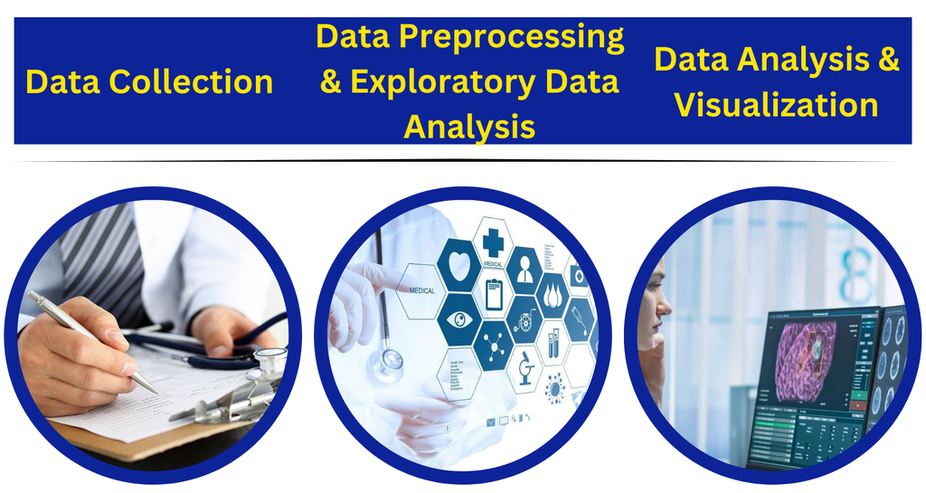

**Figure 1.** Methodology

As illustrated in **Figure 1: Methodology**, this section consists of a three-step process. It begins with data collection, followed by preprocessing of publicly available Centers for Medicare & Medicaid Services (CMS) datasets, and concludes with data analysis involving descriptive analytics and visualization.

Refer to Table 1: Methodology Details for more details about each step.

**Table 1.** Methodology Details

| NO. | STEP | DESCRIPTION |
| --- | --- | --- |
| 1. | Data Collection | Collect, assign schemas, and load the CMS datasets into Spark DataFrames. |
| 2. | Data Preprocessing and Exploratory Data Analysis (EDA) | Clean and preprocess the collected data to prepare it for analysis as well as perform simple EDA which includes handling missing values, correcting inconsistent or incorrect values, and filtering irre… |
| 3. | Data Analysis & Visualization | Utilize Apache Spark SQL or Spark DataFrame for descriptive analytics to uncover patterns and trends within the data. Conduct an analysis of procedure distribution, provider types, and costs to enhanc… |

Back to TOC

# 4. DATA COLLECTION

The first step in the methodology is to collect the necessary data. In this case, the team will be focusing on CMS Medicare datasets, specifically the `Medicare Physician & Other Practitioners - by Provider and Service` and `Medicare Part D Prescribers - by Provider and Drug` datasets. These datasets will provide a comprehensive picture of the various policies, coverage options, and prescription drug usage patterns among Medicare beneficiaries.

The **three key steps** involved in data collection section are separated into the following:

- **Identifying the data source**
- **Describing the data**
- **Collecting the data**

## 4.1 Data Source

The team utilized the available `Medicare Physician & Other Practitioners - by Provider and Service` (years 2013 to 2015) and `Medicare Part D Prescribers - by Provider and Drug` (years 2013 to 2016) sourced via the jojie-collected public datasets (directory: `/mnt/data/public/cms-gov/`) of the Asian Institute of Management (AIM).

The datasets are in text file format, separated by tab, which were easily collected and processed using Apache Spark.

Specifically, the team chose and explored the following datasets containing Medicare utilization and prescribed drug features:

- **Medicare Physician & Other Practitioners - by Provider and Service ("Medicare Physician & Other Practitioners - by Provider and Service," n.d.)**

  (directory: `/mnt/data/public/cms-gov/Medicare_Provider_Util_Payment_PUF_CY201[3-5]/*.txt`)

  This is a dataset that contains information on the utilization, payments, and submitted charges for procedures and services provided to Medicare beneficiaries by healthcare providers. The data includes information on healthcare providers, such as National Provider Identifier (NPI), provider type, and geographic location for the years 2013 to 2015. Additionally, the data includes information on the services and procedures provided, such as place of service, number of services provided to beneficiaries, and HCPCS (Healthcare Common Procedure Coding System) codes that are used to identify specific medical procedures, services, and supplies.
- **Medicare Part D Prescribers - by Provider and Drug ("Medicare Part D Prescribers - by Provider and Drug," n.d.)**

  (directory: `/mnt/data/public/cms-gov/PartD_Prescriber_PUF_NPI_DRUG_1[3-6]/*.txt`)

  This is a dataset that contains information on the prescription drugs prescribed by healthcare providers who participate in Medicare Part D, which is the prescription drug benefit program for Medicare beneficiaries. Medicare Part D is designed to help individuals afford their prescription drug costs and is provided through private insurance companies that contract with Medicare. This also contains the total number of prescription fills that were dispensed and the total drug cost paid organized by prescribing National Provider Identifier (NPI), drug brand name (if applicable) and drug generic name for the years 2013 to 2016.

## 4.2 Data Description

In this subsection, the data dictionaries of each dataset are summarized, providing details about the description, length, and data type of each feature. This aids in understanding the data and identifying any data quality issues that may require preprocessing.

Throughout this report, the following features were used and considered relevant:

- **Data by Provider and Service: ("Medicare Physician & Other Practitioners - by Provider and Service Data Dictionary," n.d.)**
  - Number of Data Points: 28,102,074
  - Number of Features: 25

**Table 2.** Data Description of Features Used: Data by Provider and Service

| Variable Name | Description | Length | Data Type |
| --- | --- | --- | --- |
| NPI | National Provider Identifier (NPI) of the provider on the claim. The provider NPI is the numeric identifier registered in the National Plan and Provider Enumeration System (NPPES). | 10 | integer |
| NPPES_PROVIDER_LAST_ORG_NAME | Last name or organization name of the provider. This is the provider’s last name if registered in NPPES as an individual (entity type code=’I’). If the provider is registered as an organization (entit… | 70 | string |
| NPPES_PROVIDER_FIRST_NAME | First name of the provider (if an individual). Otherwise, this will be blank. | 20 | string |
| NPPES_PROVIDER_MI | Middle initial of the provider (if an individual). Otherwise, this will be blank. | 1 | string |
| NPPES_CREDENTIALS | Credentials of the provider (e.g., MD, DO, DMD, etc.) if an individual. Otherwise, this will be blank. | 20 | string |
| NPPES_PROVIDER_GENDER | Gender of the provider (if an individual). Otherwise, this will be blank. | 1 | string |
| NPPES_ENTITY_CODE | Entity type of the provider ('I' for individual, 'O' for organization). | 1 | string |
| NPPES_PROVIDER_STREET1 | First line of the provider's street address. | 55 | string |
| NPPES_PROVIDER_CITY | City where the provider is located. | 40 | string |
| NPPES_PROVIDER_STATE | State abbreviation where the provider is located. | 2 | string |
| NPPES_PROVIDER_COUNTRY | Country code of the provider's address. | 2 | string |
| PROVIDER_TYPE | Type of provider (e.g., Internal Medicine, Family Practice, etc.). Derived from the provider specialty code reported on the claim. For providers that reported more than one specialty code on their cla… | 43 | string |
| MEDICARE_PARTICIPATION_INDICATOR | Indicates if the provider participates in Medicare ('Y' for yes, 'N' for no). The value will be 'Y' for any provider that had at least one claim identifying the provider as participating in Medicare o… | 1 | string |
| PLACE_OF_SERVICE | Place of service ('F' for facility, 'O' for other). Non-facility is generally an office setting; however other entities are included in non-facility. | 1 | string |
| HCPCS_CODE | Healthcare Common Procedure Coding System (HCPCS) code used to identify the specific medical service furnished by the provider. HCPCS codes include two levels. Level I codes are the Current Procedural… | 5 | integer |
| HCPCS_DESCRIPTION | Description of the HCPCS code for the specific medical service furnished by the provider. | 256 | string |
| HCPCS_DRUG_INDICATOR | Indicates if the HCPCS code is for a drug ('Y' for yes, 'N' for no). Identifies whether the HCPCS code for the specific service furnished by the provider is a HCPCS listed on the Medicare Part B Drug … | 1 | string |
| BENE_UNIQUE_CNT | Number of distinct Medicare beneficiaries receiving the service | 8 | integer |
| BENE_DAY_SRVC_CNT | Number of distinct Medicare beneficiary per day services. Since a given beneficiary may receive multiple services of the same type (e.g., single vs. multiple cardiac stents) on a single day, this metr… | 8 | integer |
| AVERAGE_MEDICARE_ALLOWED_AMT | Average of the Medicare allowed amount for the service. This figure is the sum of the amount Medicare pays, the deductible and coinsurance amounts that the beneficiary is responsible for paying, and a… | 8 | float |
| STDEV_MEDICARE_ALLOWED_AMT | Standard deviation of the Medicare allowed amount for the service | 8 | float |
| AVERAGE_SUBMITTED_CHRG_AMT | Average of the charges that the provider submitted for the service. | 8 | float |
| STDEV_SUBMITTED_CHRG_AMT | Standard deviation of the submitted charge amount for the service. | 8 | float |
| AVERAGE_MEDICARE_PAYMENT_AMT | Average Medicare payment amount for the service after deductible and coinsurance amounts have been deducted for the line item service. | 8 | float |
| STDEV_MEDICARE_PAYMENT_AMT | Standard deviation of the Medicare payment amount for the service. To be specific, this is the average amount that Medicare paid after beneficiary deductible and coinsurance amounts have been deducted… | 8 | float |

- **Data by Provider and Drugs: ("Medicare Part D Prescribers - by Provider and Drug Data Dictionary," n.d.)**
  - Number of Data Points: 97,255,685
  - Number of Features: 18

**Table 3.** Data Description of Features Used: Data by Provider and Drug

| Variable Name | Description | Length | Data Type |
| --- | --- | --- | --- |
| npi | NPI of the provider on the claim. | 10 | integer |
| nppes_provider_last_org_name | Last name or organization name of the provider. | 70 | string |
| nppes_provider_first_name | First name of the provider (if an individual). | 20 | string |
| nppes_provider_city | City where the provider is located. | 40 | string |
| nppes_provider_state | State abbreviation where the provider is located. | 2 | string |
| specialty_description | Description of the provider's specialty. | 75 | string |
| description_flag | Indicates the source of the specialty description ('S' for self-reported, 'C' for CMS-generated) | 1 | string |
| drug_name | Brand name of the drug | 30 | string |
| generic_name | Generic name of the drug | 30 | string |
| total_claim_count | Total number of Medicare Part D claims for the drug | 8 | integer |
| total_day_supply | Total number of days' supply of the drug | 8 | string |
| total_drug_cost | Total cost of the drug | 8 | float |
| bene_count_ge65 | Number of distinct Medicare beneficiaries aged 65 and over receiving the drug | 8 | integer |
| bene_count_ge65_suppress_flag | Flag to indicate if the beneficiary count for 65 and over is suppressed ('*' if suppressed) | 1 | integer |
| total_claim_count_ge65 | Total number of Medicare Part D claims for the drug for beneficiaries aged 65 and over | 8 | integer |
| ge65_suppress_flag | Flag to indicate if claim count for 65 and over is suppressed ('*' if suppressed) | 1 | string |
| total_day_supply_ge65 | Total number of days' supply of the drug for beneficiaries aged 65 and over | 8 | integer |
| total_drug_cost_ge65 | Total cost of the drug for beneficiaries aged 65 and over | 8 | float |

## 4.3 Data Collection

The following steps demonstrate the collection and loading of the two CMS datasets into Spark DataFrames, with appropriate schemas assigned to each dataset.

### 4.3.1 Create a Spark Session

```python
# Create a Spark Session
spark = (SparkSession
         .builder
         .master('local[*]')
         .getOrCreate())

# Disable logging messages
spark.sparkContext.setLogLevel('OFF')
display(HTML(f'<b>SparkSession created.</b>'))
```

**SparkSession created.**

### 4.3.2 Load and store the dataset in a Spark DataFrame format

This subsection includes setting up the schema, reading the file using `spark.read.csv()`, displaying three random rows from the DataFrame, and printing the updated schema.

#### 4.3.2.1 Medicare Physician and Other Practitioners - by Provider and Service

```python
# Set the schema for service
schema_service = StructType([
    StructField('NPI', IntegerType()),
    StructField('NPPES_PROVIDER_LAST_ORG_NAME', StringType()),
    StructField('NPPES_PROVIDER_FIRST_NAME', StringType()),
    StructField('NPPES_PROVIDER_MI', StringType()),
    StructField('NPPES_CREDENTIALS', StringType()),
    StructField('NPPES_PROVIDER_GENDER', StringType()),
    StructField('NPPES_ENTITY_CODE', StringType()),
    StructField('NPPES_PROVIDER_STREET1', StringType()),
    StructField('NPPES_PROVIDER_STREET2', StringType()),
    StructField('NPPES_PROVIDER_CITY', StringType()),
    StructField('NPPES_PROVIDER_ZIP', IntegerType()),
    StructField('NPPES_PROVIDER_STATE', StringType()),
    StructField('NPPES_PROVIDER_COUNTRY', StringType()),
    StructField('PROVIDER_TYPE', StringType()),
    StructField('MEDICARE_PARTICIPATION_INDICATOR', StringType()),
    StructField('PLACE_OF_SERVICE', StringType()),
    StructField('HCPCS_CODE', IntegerType()),
    StructField('HCPCS_DESCRIPTION', StringType()),
    StructField('HCPCS_DRUG_INDICATOR', StringType()),
    StructField('LINE_SRVC_CNT', IntegerType()),
    StructField('BENE_UNIQUE_CNT', IntegerType()),
    StructField('BENE_DAY_SRVC_CNT', IntegerType()),
    StructField('AVERAGE_MEDICARE_ALLOWED_AMT', DoubleType()),
    StructField('STDEV_MEDICARE_ALLOWED_AMT', DoubleType()),
    StructField('AVERAGE_SUBMITTED_CHRG_AMT', DoubleType()),
    StructField('STDEV_SUBMITTED_CHRG_AMT', DoubleType()),
    StructField('AVERAGE_MEDICARE_PAYMENT_AMT', DoubleType()),
    StructField('STDEV_MEDICARE_PAYMENT_AMT', DoubleType()),
])


# Read the file as csv with '\t' as the separator & schema_service for schema
provider_service = (spark.read.csv(filepath_svc,
                                   sep="\t",
                                   header=True,
                                   schema=schema_service))


# Sample 3 rows from the data
display(HTML(f'<b>Sample three rows of the provider_service data:</b>'))
display(provider_service.limit(30).toPandas().sample(3))


# Display the schema
display(HTML(f'<b>Updated schema of the provider_service data:</b>'))
provider_service.printSchema()
```

**Sample three rows of the provider_service data:**

|  | NPI | NPPES_PROVIDER_LAST_ORG_NAME | NPPES_PROVIDER_FIRST_NAME | NPPES_PROVIDER_MI | NPPES_CREDENTIALS | NPPES_PROVIDER_GENDER | NPPES_ENTITY_CODE | NPPES_PROVIDER_STREET1 | NPPES_PROVIDER_STREET2 | NPPES_PROVIDER_CITY | NPPES_PROVIDER_ZIP | NPPES_PROVIDER_STATE | NPPES_PROVIDER_COUNTRY | PROVIDER_TYPE | MEDICARE_PARTICIPATION_INDICATOR | PLACE_OF_SERVICE | HCPCS_CODE | HCPCS_DESCRIPTION | HCPCS_DRUG_INDICATOR | LINE_SRVC_CNT | BENE_UNIQUE_CNT | BENE_DAY_SRVC_CNT | AVERAGE_MEDICARE_ALLOWED_AMT | STDEV_MEDICARE_ALLOWED_AMT | AVERAGE_SUBMITTED_CHRG_AMT | STDEV_SUBMITTED_CHRG_AMT | AVERAGE_MEDICARE_PAYMENT_AMT | STDEV_MEDICARE_PAYMENT_AMT |
| --- | --- | --- | --- | --- | --- | --- | --- | --- | --- | --- | --- | --- | --- | --- | --- | --- | --- | --- | --- | --- | --- | --- | --- | --- | --- | --- | --- | --- |
| 8 | 1003000134 | CIBULL | THOMAS | L | M.D. | M | I | 2650 RIDGE AVE | EVANSTON HOSPITAL | EVANSTON | 602011718.0 | IL | US | Pathology | Y | F | 88304.0 | Pathology examination of tissue using a microscope, moderately low complexity | N | 209.0 | 201.0 | 204.0 | 11.990000 | 0.00000 | 115.000000 | 0.000000 | 9.327464 | 0.976977 |
| 6 | 1003000126 | ENKESHAFI | ARDALAN | None | M.D. | M | I | 900 SETON DR | None | CUMBERLAND | 215021854.0 | MD | US | Internal Medicine | Y | F | 99238.0 | Hospital discharge day management, 30 minutes or less | N | 219.0 | 208.0 | 219.0 | 72.090000 | 0.00000 | 201.004566 | 39.390736 | 55.650457 | 7.601205 |
| 17 | 1003000142 | KHALIL | RASHID | None | M.D. | M | I | 4126 N HOLLAND SYLVANIA RD | SUITE 220 | TOLEDO | 436233536.0 | OH | US | Anesthesiology | Y | F | 64493.0 | Injection of lower spine facet joint using imaging guidance | N | 22.0 | 13.0 | 22.0 | 133.818182 | 13.22407 | 709.136364 | 161.015046 | 105.414091 | 10.564828 |

**Updated schema of the provider_service data:**

```
root
 |-- NPI: integer (nullable = true)
 |-- NPPES_PROVIDER_LAST_ORG_NAME: string (nullable = true)
 |-- NPPES_PROVIDER_FIRST_NAME: string (nullable = true)
 |-- NPPES_PROVIDER_MI: string (nullable = true)
 |-- NPPES_CREDENTIALS: string (nullable = true)
 |-- NPPES_PROVIDER_GENDER: string (nullable = true)
 |-- NPPES_ENTITY_CODE: string (nullable = true)
 |-- NPPES_PROVIDER_STREET1: string (nullable = true)
 |-- NPPES_PROVIDER_STREET2: string (nullable = true)
 |-- NPPES_PROVIDER_CITY: string (nullable = true)
 |-- NPPES_PROVIDER_ZIP: integer (nullable = true)
 |-- NPPES_PROVIDER_STATE: string (nullable = true)
 |-- NPPES_PROVIDER_COUNTRY: string (nullable = true)
 |-- PROVIDER_TYPE: string (nullable = true)
 |-- MEDICARE_PARTICIPATION_INDICATOR: string (nullable = true)
 |-- PLACE_OF_SERVICE: string (nullable = true)
 |-- HCPCS_CODE: integer (nullable = true)
 |-- HCPCS_DESCRIPTION: string (nullable = true)
 |-- HCPCS_DRUG_INDICATOR: string (nullable = true)
 |-- LINE_SRVC_CNT: integer (nullable = true)
 |-- BENE_UNIQUE_CNT: integer (nullable = true)
 |-- BENE_DAY_SRVC_CNT: integer (nullable = true)
 |-- AVERAGE_MEDICARE_ALLOWED_AMT: double (nullable = true)
 |-- STDEV_MEDICARE_ALLOWED_AMT: double (nullable = true)
 |-- AVERAGE_SUBMITTED_CHRG_AMT: double (nullable = true)
 |-- STDEV_SUBMITTED_CHRG_AMT: double (nullable = true)
 |-- AVERAGE_MEDICARE_PAYMENT_AMT: double (nullable = true)
 |-- STDEV_MEDICARE_PAYMENT_AMT: double (nullable = true)
```

#### 4.3.2.2 Medicare Part D Prescribers - by Provider and Drug

```python
# Set schema
schema_drug = StructType([
    StructField('npi', IntegerType()),
    StructField('nppes_provider_last_org_name', StringType()),
    StructField('nppes_provider_first_name', StringType()),
    StructField('nppes_provider_city', StringType()),
    StructField('nppes_provider_state', StringType()),
    StructField('specialty_description', StringType()),
    StructField('description_flag', StringType()),
    StructField('drug_name', StringType()),
    StructField('generic_name', StringType()),
    StructField('bene_count', IntegerType()),
    StructField('total_claim_count', IntegerType()),
    StructField('total_30_day_fill_count', IntegerType()),
    StructField('total_day_supply', IntegerType()),
    StructField('total_drug_cost', DoubleType()),
    StructField('bene_count_ge65', IntegerType()),
    StructField('bene_count_ge65_suppress_flag', StringType()),
    StructField('total_claim_count_ge65', IntegerType()),
    StructField('ge65_suppress_flag', StringType()),
    StructField('total_30_day_fill_count_ge65', IntegerType()),
    StructField('total_day_supply_ge65', IntegerType()),
    StructField('total_drug_cost_ge65', DoubleType()),
])

# Read the text file as csv with new tab as the separator & use schema_service
provider_drug = (spark.read.csv(filepath_drug,
                                sep="\t",
                                header=True,
                                schema=schema_drug))

# Sample first 3 data
display(HTML(f'<b>Sample three rows of the provider_drug data:</b>'))
display(provider_drug.limit(30).toPandas().sample(3))

# Display the schema
display(HTML(f'<b>Updated schema of the provider_drug data:</b>'))
provider_drug.printSchema()
```

**Sample three rows of the provider_drug data:**

|  | npi | nppes_provider_last_org_name | nppes_provider_first_name | nppes_provider_city | nppes_provider_state | specialty_description | description_flag | drug_name | generic_name | bene_count | total_claim_count | total_30_day_fill_count | total_day_supply | total_drug_cost | bene_count_ge65 | bene_count_ge65_suppress_flag | total_claim_count_ge65 | ge65_suppress_flag | total_30_day_fill_count_ge65 | total_day_supply_ge65 | total_drug_cost_ge65 |
| --- | --- | --- | --- | --- | --- | --- | --- | --- | --- | --- | --- | --- | --- | --- | --- | --- | --- | --- | --- | --- | --- |
| 14 | 1003000142 | KHALIL | RASHID | TOLEDO | OH | Anesthesiology | S | MELOXICAM | MELOXICAM | NaN | 31 | 32.0 | 840 | 187.69 | NaN | * | NaN | * | NaN | NaN | NaN |
| 15 | 1003000142 | KHALIL | RASHID | TOLEDO | OH | Anesthesiology | S | OXYCODONE HCL-ACETAMINOPHEN | OXYCODONE HCL/ACETAMINOPHEN | NaN | 11 | 11.0 | 263 | 555.87 | NaN | * | NaN | * | NaN | NaN | NaN |
| 0 | 1003000126 | ENKESHAFI | ARDALAN | CUMBERLAND | MD | Internal Medicine | S | ISOSORBIDE MONONITRATE ER | ISOSORBIDE MONONITRATE | NaN | 11 | 11.0 | 307 | 171.59 | NaN | * | NaN | * | NaN | NaN | NaN |

**Updated schema of the provider_drug data:**

```
root
 |-- npi: integer (nullable = true)
 |-- nppes_provider_last_org_name: string (nullable = true)
 |-- nppes_provider_first_name: string (nullable = true)
 |-- nppes_provider_city: string (nullable = true)
 |-- nppes_provider_state: string (nullable = true)
 |-- specialty_description: string (nullable = true)
 |-- description_flag: string (nullable = true)
 |-- drug_name: string (nullable = true)
 |-- generic_name: string (nullable = true)
 |-- bene_count: integer (nullable = true)
 |-- total_claim_count: integer (nullable = true)
 |-- total_30_day_fill_count: integer (nullable = true)
 |-- total_day_supply: integer (nullable = true)
 |-- total_drug_cost: double (nullable = true)
 |-- bene_count_ge65: integer (nullable = true)
 |-- bene_count_ge65_suppress_flag: string (nullable = true)
 |-- total_claim_count_ge65: integer (nullable = true)
 |-- ge65_suppress_flag: string (nullable = true)
 |-- total_30_day_fill_count_ge65: integer (nullable = true)
 |-- total_day_supply_ge65: integer (nullable = true)
 |-- total_drug_cost_ge65: double (nullable = true)
```

Back to TOC

# 5. DATA PREPROCESSING AND EDA

In this section, the datasets undergo preprocessing and cleaning procedures, including the handling of missing values and filtering out irrelevant records, along with other exploratory data analysis (EDA) techniques. These steps guarantee that the datasets are prepared for analysis and that the resulting insights derived from the data are dependable.

## 5.1 Preview Data & Check for Null Values

```python
preview_df("Data by Provider & Service", provider_service, display_nulls=True)
```

**Data Label:** Data by Provider & Service

**Number of Data Points:** 28102077

**Number of Features:** 28

**Columns with null values:**

|  | Column | Null Count |
| --- | --- | --- |
| 0 | NPPES_PROVIDER_FIRST_NAME | 1232816 |
| 1 | NPPES_PROVIDER_MI | 7605820 |
| 2 | NPPES_CREDENTIALS | 1810075 |
| 3 | NPPES_PROVIDER_GENDER | 1232816 |
| 4 | NPPES_ENTITY_CODE | 3 |
| 5 | NPPES_PROVIDER_STREET1 | 3 |
| 6 | NPPES_PROVIDER_STREET2 | 15608800 |
| 7 | NPPES_PROVIDER_CITY | 3 |
| 8 | NPPES_PROVIDER_ZIP | 583 |
| 9 | NPPES_PROVIDER_STATE | 3 |
| 10 | NPPES_PROVIDER_COUNTRY | 3 |
| 11 | PROVIDER_TYPE | 3 |
| 12 | MEDICARE_PARTICIPATION_INDICATOR | 3 |
| 13 | PLACE_OF_SERVICE | 3 |
| 14 | HCPCS_CODE | 2924454 |
| 15 | HCPCS_DESCRIPTION | 3 |
| 16 | HCPCS_DRUG_INDICATOR | 3 |
| 17 | LINE_SRVC_CNT | 31478 |
| 18 | BENE_UNIQUE_CNT | 3 |
| 19 | BENE_DAY_SRVC_CNT | 3 |
| 20 | AVERAGE_MEDICARE_ALLOWED_AMT | 3 |
| 21 | STDEV_MEDICARE_ALLOWED_AMT | 3 |
| 22 | AVERAGE_SUBMITTED_CHRG_AMT | 3 |
| 23 | STDEV_SUBMITTED_CHRG_AMT | 3 |
| 24 | AVERAGE_MEDICARE_PAYMENT_AMT | 18814201 |
| 25 | STDEV_MEDICARE_PAYMENT_AMT | 18814201 |

**Preview of the dataframe:**

|  | NPI | NPPES_PROVIDER_LAST_ORG_NAME | NPPES_PROVIDER_FIRST_NAME | NPPES_PROVIDER_MI | NPPES_CREDENTIALS | NPPES_PROVIDER_GENDER | NPPES_ENTITY_CODE | NPPES_PROVIDER_STREET1 | NPPES_PROVIDER_STREET2 | NPPES_PROVIDER_CITY | NPPES_PROVIDER_ZIP | NPPES_PROVIDER_STATE | NPPES_PROVIDER_COUNTRY | PROVIDER_TYPE | MEDICARE_PARTICIPATION_INDICATOR | PLACE_OF_SERVICE | HCPCS_CODE | HCPCS_DESCRIPTION | HCPCS_DRUG_INDICATOR | LINE_SRVC_CNT | BENE_UNIQUE_CNT | BENE_DAY_SRVC_CNT | AVERAGE_MEDICARE_ALLOWED_AMT | STDEV_MEDICARE_ALLOWED_AMT | AVERAGE_SUBMITTED_CHRG_AMT | STDEV_SUBMITTED_CHRG_AMT | AVERAGE_MEDICARE_PAYMENT_AMT | STDEV_MEDICARE_PAYMENT_AMT |
| --- | --- | --- | --- | --- | --- | --- | --- | --- | --- | --- | --- | --- | --- | --- | --- | --- | --- | --- | --- | --- | --- | --- | --- | --- | --- | --- | --- | --- |
| 0 | 1 | CPT copyright 2012 American Medical Association. All Rights Reserved. | None | None | None | None | None | None | None | None | NaN | None | None | None | None | None | NaN | None | None | NaN | NaN | NaN | NaN | NaN | NaN | NaN | NaN | NaN |
| 1 | 1003000126 | ENKESHAFI | ARDALAN | None | M.D. | M | I | 900 SETON DR | None | CUMBERLAND | 215021854.0 | MD | US | Internal Medicine | Y | F | 99222.0 | Initial hospital inpatient care, typically 50 minutes per day | N | 142.0 | 138.0 | 142.0 | 136.452324 | 6.028319 | 368.626761 | 89.642452 | 104.299718 | 17.890405 |
| 2 | 1003000126 | ENKESHAFI | ARDALAN | None | M.D. | M | I | 900 SETON DR | None | CUMBERLAND | 215021854.0 | MD | US | Internal Medicine | Y | F | 99223.0 | Initial hospital inpatient care, typically 70 minutes per day | N | 96.0 | 95.0 | 96.0 | 201.320000 | 0.000000 | 524.604167 | 141.760470 | 155.901146 | 19.510660 |

#### Comments / Insights:

- **Large dataset**: This dataset contains over 28 million data points and 28 features.
- **Small number of missing values (count==3)**: Rows with missing values for each of the columns with three null counts can be removed without significantly impacting the analysis. Upon checking, it is because of a line with "CPT copyright 2012 American Medical Associatio..." that was erroneously converted from text and added as part of the Spark DataFrame during the data collection and loading step. Such line has `NPI=1`, so it will be removed in the next subsection.
- **Missing values**: Multiple columns have more than three missing values. Based on the nature of each column, the team assessed the following:
  - `NPPES_PROVIDER_FIRST_NAME`, `NPPES_PROVIDER_MI`, `NPPES_CREDENTIALS`, `NPPES_PROVIDER_GENDER`: These features are dependent on the `NPPES_ENTITY_CODE` feature, where if the provider is an organization, these columns will be kept blank. So these null values are valid and no further preprocessing action is needed to be performed.
  - `NPPES_PROVIDER_STREET2`, `NPPES_PROVIDER_ZIP`, `LINE_SRVC_CNT`: These features are optional and will not be used for this analysis, so no action needed.
  - The `HCPCS_CODE` column has around 2.9 million missing values. This is important information as HCPCS codes are used to identify specific medical procedures, services, and supplies. However, considering that the `HCPCS_DESCRIPTION` has only three missing values, this feature could be used for analysis instead, so no action needed here as well.
  - Features `AVERAGE_MEDICARE_PAYMENT_AMT` and `STDEV_MEDICARE_PAYMENT_AMT` have a substantial number of missing values (over 18.8 million). These pertain to the Average and Standard deviation of Medicare payment amount for the service after deductible and coinsurance amounts have been deducted for the line item service. With that nature of account, it is possible that the net average/stdev payment result are zero for most claims. Hence, no further action is needed for these columns.

```python
preview_df("Data by Provider & Drug", provider_drug, display_nulls=True)
```

**Data Label:** Data by Provider & Drug

**Number of Data Points:** 97255685

**Number of Features:** 21

**Columns with null values:**

|  | Column | Null Count |
| --- | --- | --- |
| 0 | nppes_provider_first_name | 1969 |
| 1 | bene_count | 60269088 |
| 2 | total_30_day_fill_count | 16628824 |
| 3 | bene_count_ge65 | 83888185 |
| 4 | bene_count_ge65_suppress_flag | 13367500 |
| 5 | total_claim_count_ge65 | 40927100 |
| 6 | ge65_suppress_flag | 56328585 |
| 7 | total_30_day_fill_count_ge65 | 49423709 |
| 8 | total_day_supply_ge65 | 40927100 |
| 9 | total_drug_cost_ge65 | 40927100 |

**Preview of the dataframe:**

|  | npi | nppes_provider_last_org_name | nppes_provider_first_name | nppes_provider_city | nppes_provider_state | specialty_description | description_flag | drug_name | generic_name | bene_count | total_claim_count | total_30_day_fill_count | total_day_supply | total_drug_cost | bene_count_ge65 | bene_count_ge65_suppress_flag | total_claim_count_ge65 | ge65_suppress_flag | total_30_day_fill_count_ge65 | total_day_supply_ge65 | total_drug_cost_ge65 |
| --- | --- | --- | --- | --- | --- | --- | --- | --- | --- | --- | --- | --- | --- | --- | --- | --- | --- | --- | --- | --- | --- |
| 0 | 1003000126 | ENKESHAFI | ARDALAN | CUMBERLAND | MD | Internal Medicine | S | ISOSORBIDE MONONITRATE ER | ISOSORBIDE MONONITRATE | NaN | 11 | 11 | 307 | 171.59 | NaN | * | NaN | * | NaN | NaN | NaN |
| 1 | 1003000126 | ENKESHAFI | ARDALAN | CUMBERLAND | MD | Internal Medicine | S | LEVOFLOXACIN | LEVOFLOXACIN | 26.0 | 26 | 26 | 165 | 227.10 | 15.0 | None | 15.0 | None | 15.0 | 106.0 | 159.72 |
| 2 | 1003000126 | ENKESHAFI | ARDALAN | CUMBERLAND | MD | Internal Medicine | S | LISINOPRIL | LISINOPRIL | 17.0 | 19 | 19 | 570 | 100.37 | NaN | # | NaN | # | NaN | NaN | NaN |

#### Comments / Insights:

- **Large dataset**: This dataset contains over 97 million data points and 21 features.
- **Missing values**: Multiple columns have missing values. Based on the nature of each column, the team assessed the following:
  - `nppes_provider_first_name`: This feature is dependent on the `NPPES_ENTITY_CODE` feature, where if the provider is an organization, this column will be kept blank. So the null values in this column are valid and no further preprocessing action is needed to be performed.
  - **Drop**: `bene_count`, `total_30_day_fill_count`, and `total_30_day_fill_count_ge65` will be dropped because of the number of their null values and the fact that they are deemed unfit for analysis.
  - **Interdependent features**: `bene_count_ge65` and `ge65_suppress_flag` - `bene_count_ge65` just means that this is the number of distinct Medicare beneficiaries aged 65 and over who are receiving the drugs. While `ge65_suppress_flag` is used to indicate if the beneficiary count for 65 and over is suppressed. Likewise, `total_claim_count_ge65` and `ge65_suppress_flag` pertain to whether or not the total number of Medicare Part D claims for the drug are for 65 and over or not. Both pairs, when added, are equal to the total data points, over 97 million.
  - `total_day_supply_ge65` and `total_drug_cost_ge65` are both related to `total_claim_count_ge65`. The former features are just the supply and drug costs for claims made by the beneficiaries with details in `total_claim_count_ge65`.

## 5.2 Remove Null Values & Edit Incorrect Names

As summarized in the previous section, the following will be performed in the succeeding cells for the rows and columns of each dataset:

- Drop the columns with three rows missing pertain to `NPI=1` rows of provider_service dataset.
- Drop the columns with high null values and deemed irrelevant for the team's analytics purpose.
- Correct the names of NPI # 1912175340.

### 5.2.1 Drop the columns with three rows missing pertain to NPI=1 rows of provider_service dataset

```python
provider_service = drop_nulls(provider_service)
```

**Dropping rows with NPI=1 in provider_service df:**

|  | NPI | NPPES_PROVIDER_LAST_ORG_NAME | NPPES_PROVIDER_FIRST_NAME | NPPES_PROVIDER_MI | NPPES_CREDENTIALS | NPPES_PROVIDER_GENDER | NPPES_ENTITY_CODE | NPPES_PROVIDER_STREET1 | NPPES_PROVIDER_STREET2 | NPPES_PROVIDER_CITY | NPPES_PROVIDER_ZIP | NPPES_PROVIDER_STATE | NPPES_PROVIDER_COUNTRY | PROVIDER_TYPE | MEDICARE_PARTICIPATION_INDICATOR | PLACE_OF_SERVICE | HCPCS_CODE | HCPCS_DESCRIPTION | HCPCS_DRUG_INDICATOR | LINE_SRVC_CNT | BENE_UNIQUE_CNT | BENE_DAY_SRVC_CNT | AVERAGE_MEDICARE_ALLOWED_AMT | STDEV_MEDICARE_ALLOWED_AMT | AVERAGE_SUBMITTED_CHRG_AMT | STDEV_SUBMITTED_CHRG_AMT | AVERAGE_MEDICARE_PAYMENT_AMT | STDEV_MEDICARE_PAYMENT_AMT |
| --- | --- | --- | --- | --- | --- | --- | --- | --- | --- | --- | --- | --- | --- | --- | --- | --- | --- | --- | --- | --- | --- | --- | --- | --- | --- | --- | --- | --- |
| 0 | 1 | CPT copyright 2012 American Medical Association. All Rights Reserved. | None | None | None | None | None | None | None | None | NaN | None | None | None | None | None | NaN | None | None | NaN | NaN | NaN | NaN | NaN | NaN | NaN | NaN | NaN |
| 1 | 1 | CPT copyright 2013 American Medical Association. All Rights Reserved. | None | None | None | None | None | None | None | None | NaN | None | None | None | None | None | NaN | None | None | NaN | NaN | NaN | NaN | NaN | NaN | NaN | NaN | NaN |
| 2 | 1 | CPT copyright 2014 American Medical Association. All Rights Reserved. | None | None | None | None | None | None | None | None | NaN | None | None | None | None | None | NaN | None | None | NaN | NaN | NaN | NaN | NaN | NaN | NaN | NaN | NaN |

**Dropping complete.**

### 5.2.2 Drop the columns with high null values and deemed irrelevant for the team's analytics purpose

```python
# Drop columns
provider_service = drop_columns("Data by Provider & Service",
                                provider_service,
                                ['NPPES_PROVIDER_STREET2',
                                 'NPPES_PROVIDER_ZIP',
                                 'LINE_SRVC_CNT'])

provider_drug = drop_columns("Data by Provider & Drug",
                             provider_drug,
                             ['bene_count', 'total_30_day_fill_count',
                              'total_30_day_fill_count_ge65'])
```

**Data Label:** Data by Provider & Service

**Dropped columns: ['NPPES_PROVIDER_STREET2', 'NPPES_PROVIDER_ZIP', 'LINE_SRVC_CNT']**

**Data Label:** Data by Provider & Drug

**Dropped columns: ['bene_count', 'total_30_day_fill_count', 'total_30_day_fill_count_ge65']**

### 5.2.3 Correct the names for each transaction of a provider with NPI # 1912175340

```python
# Clean names of data by provider and service
provider_service = clean_names_service("Data by Provider & Service",
                                       provider_service)
```

**Data Label:** Data by Provider & Service

**Correcting the first & last name of NPI#1912175340 ...**

**Task completed.**

```python
# Clean names of data by provider and drug
provider_drug = clean_names_drug("Data by Provider & Drug", provider_drug)
```

**Data Label:** Data by Provider & Drug

**Correcting the first and last name of NPI#1912175340 ...**

**Task completed.**

## 5.3 Display Cleaned Datasets

```python
# Display the cleaned dataframe for Data by Provider & Service
preview_service("Data by Provider & Service", provider_service)
```

**Data Label:** Data by Provider & Service

**Number of Data Points:** 28102074

**Number of Features:** 25

**Preview of the dataframe:**

**Table 4.** Cleaned DataFrame: Data by Provider and Service

|  | NPI | NPPES_PROVIDER_LAST_ORG_NAME | NPPES_PROVIDER_FIRST_NAME | NPPES_PROVIDER_MI | NPPES_CREDENTIALS | NPPES_PROVIDER_GENDER | NPPES_ENTITY_CODE | NPPES_PROVIDER_STREET1 | NPPES_PROVIDER_CITY | NPPES_PROVIDER_STATE | NPPES_PROVIDER_COUNTRY | PROVIDER_TYPE | MEDICARE_PARTICIPATION_INDICATOR | PLACE_OF_SERVICE | HCPCS_CODE | HCPCS_DESCRIPTION | HCPCS_DRUG_INDICATOR | BENE_UNIQUE_CNT | BENE_DAY_SRVC_CNT | AVERAGE_MEDICARE_ALLOWED_AMT | STDEV_MEDICARE_ALLOWED_AMT | AVERAGE_SUBMITTED_CHRG_AMT | STDEV_SUBMITTED_CHRG_AMT | AVERAGE_MEDICARE_PAYMENT_AMT | STDEV_MEDICARE_PAYMENT_AMT |
| --- | --- | --- | --- | --- | --- | --- | --- | --- | --- | --- | --- | --- | --- | --- | --- | --- | --- | --- | --- | --- | --- | --- | --- | --- | --- |
| 0 | 1003000126 | ENKESHAFI | ARDALAN | None | M.D. | M | I | 900 SETON DR | CUMBERLAND | MD | US | Internal Medicine | Y | F | 99222 | Initial hospital inpatient care, typically 50 minutes per day | N | 138 | 142 | 136.452324 | 6.028319 | 368.626761 | 89.642452 | 104.299718 | 17.890405 |
| 1 | 1003000126 | ENKESHAFI | ARDALAN | None | M.D. | M | I | 900 SETON DR | CUMBERLAND | MD | US | Internal Medicine | Y | F | 99223 | Initial hospital inpatient care, typically 70 minutes per day | N | 95 | 96 | 201.320000 | 0.000000 | 524.604167 | 141.760470 | 155.901146 | 19.510660 |
| 2 | 1003000126 | ENKESHAFI | ARDALAN | None | M.D. | M | I | 900 SETON DR | CUMBERLAND | MD | US | Internal Medicine | Y | F | 99231 | Subsequent hospital inpatient care, typically 15 minutes per day | N | 47 | 61 | 38.740000 | 0.000000 | 97.000000 | 29.291637 | 30.065246 | 3.891932 |

```python
# Display the cleaned dataframe for Data by Provider & Drug
preview_drug("Data by Provider & Drug", provider_drug)
```

**Data Label:** Data by Provider & Drug

**Number of Data Points:** 97255685

**Number of Features:** 18

**Preview of the dataframe:**

**Table 5.** Cleaned DataFrame: Data by Provider and Drug

|  | npi | nppes_provider_last_org_name | nppes_provider_first_name | nppes_provider_city | nppes_provider_state | specialty_description | description_flag | drug_name | generic_name | total_claim_count | total_day_supply | total_drug_cost | bene_count_ge65 | bene_count_ge65_suppress_flag | total_claim_count_ge65 | ge65_suppress_flag | total_day_supply_ge65 | total_drug_cost_ge65 |
| --- | --- | --- | --- | --- | --- | --- | --- | --- | --- | --- | --- | --- | --- | --- | --- | --- | --- | --- |
| 0 | 1003000126 | ENKESHAFI | ARDALAN | CUMBERLAND | MD | Internal Medicine | S | ISOSORBIDE MONONITRATE ER | ISOSORBIDE MONONITRATE | 11 | 307 | 171.59 | NaN | * | NaN | * | NaN | NaN |
| 1 | 1003000126 | ENKESHAFI | ARDALAN | CUMBERLAND | MD | Internal Medicine | S | LEVOFLOXACIN | LEVOFLOXACIN | 26 | 165 | 227.10 | 15.0 | None | 15.0 | None | 106.0 | 159.72 |
| 2 | 1003000126 | ENKESHAFI | ARDALAN | CUMBERLAND | MD | Internal Medicine | S | LISINOPRIL | LISINOPRIL | 19 | 570 | 100.37 | NaN | # | NaN | # | NaN | NaN |

## 5.4 Display Statistics

Tables 6 and 7 below provide a summary of the statistical calculations.

```python
# Describe provider_service data
display(HTML(f'<left><span style="color:gray; font-size:16px"><b>Table 6. '
             f'</b>Statistics: Data by Provider and Service</span></left>'))
provider_service.describe().toPandas()
```

**Table 6.** Statistics: Data by Provider and Service

|  | summary | NPI | NPPES_PROVIDER_LAST_ORG_NAME | NPPES_PROVIDER_FIRST_NAME | NPPES_PROVIDER_MI | NPPES_CREDENTIALS | NPPES_PROVIDER_GENDER | NPPES_ENTITY_CODE | NPPES_PROVIDER_STREET1 | NPPES_PROVIDER_CITY | NPPES_PROVIDER_STATE | NPPES_PROVIDER_COUNTRY | PROVIDER_TYPE | MEDICARE_PARTICIPATION_INDICATOR | PLACE_OF_SERVICE | HCPCS_CODE | HCPCS_DESCRIPTION | HCPCS_DRUG_INDICATOR | BENE_UNIQUE_CNT | BENE_DAY_SRVC_CNT | AVERAGE_MEDICARE_ALLOWED_AMT | STDEV_MEDICARE_ALLOWED_AMT | AVERAGE_SUBMITTED_CHRG_AMT | STDEV_SUBMITTED_CHRG_AMT | AVERAGE_MEDICARE_PAYMENT_AMT | STDEV_MEDICARE_PAYMENT_AMT |
| --- | --- | --- | --- | --- | --- | --- | --- | --- | --- | --- | --- | --- | --- | --- | --- | --- | --- | --- | --- | --- | --- | --- | --- | --- | --- | --- |
| 0 | count | 28102074 | 28102074 | 26869261 | 20496257 | 26292002 | 26869261 | 28102074 | 28102074 | 28102074 | 28102074 | 28102074 | 28102074 | 28102074 | 28102074 | 25177623 | 28102074 | 28102074 | 28102074 | 28102074 | 28102074 | 28102074 | 28102074 | 28102074 | 9287876 | 9287876 |
| 1 | mean | 1.4996794607690482E9 | NaN | NaN | 0.1875 | None | None | None | 147974.81451612903 | 49519.0 | None | None | None | None | None | 80441.62247143028 | None | None | 90.87070754991251 | 148.7013639278012 | 98.29712366890635 | 218.06334808401115 | 152.87372123341453 | 59.21008243665287 | 74.21857476025221 | 12.626028750517495 |
| 2 | stddev | 2.878218481577731E8 | NaN | NaN | 0.4031128874149275 | None | None | None | 347412.6569920361 | 0.0 | None | None | None | None | None | 25777.3714044871 | None | None | 1148.2007579931617 | 2366.2620020043832 | 226.19127012771344 | 762.1248911336467 | 519.8709005653324 | 180.9728523395094 | 166.27810538208453 | 41.53268986712575 |
| 3 | min | 1003000126 | 0424 INC | (ALYCEA) | ' | (D.C.) CHIROPRACTIC | F | I | # 1 BURDICK EXPY W | /WALDPORT | AA | AE | Addiction Medicine | N | F | 100 | "Orthotic and prosthetic supply, accessory, and/or service component of another hcpcs ""l"" code" | N | 11 | 11 | 1.004415E-4 | 0.0 | 0.0 | 0.0 | 0.0 | 0.0 |
| 4 | max | 1992999874 | ZZIWAMBAZZA | ZYNNIA | ` | Z,F | M | O | ZRB 739 | ZWOLLE | ZZ | VE | Vascular Surgery | Y | O | 99499 | b-Hexosaminidase (enzyme) level | Y | 741837 | 2290882 | 52601.47126 | 99999.99 | 98099.82 | 60858.176833 | 34334.025187 | 31932.174744 |

#### Comments / Insights:

- **NPI**: The National Provider Identifier (NPI), in Table 6, is a unique identification number for covered healthcare providers. The mean and standard deviation here aren't particularly meaningful since this is an identifier. However, the count suggests that the dataset includes over 28 million unique provider-service instances.
- **Variability in Services and Charges:** The high standard deviations for average Medicare allowed amount, submitted charges, and Medicare payment suggest significant variability in the types of services provided and the charges associated with these services. This reflects the diverse healthcare needs of the patient population and the different pricing models of healthcare providers.
- **High-Volume Service Providers:** The average beneficiary day service count is considerably higher than the unique beneficiary count. This indicates that some patients are using services multiple times, suggesting that certain health conditions may require frequent or ongoing services.
- **Significant Medicare Payments:** The average Medicare payment amount is substantial at `$74.22`. This suggests that Medicare plays a vital role in financing healthcare services for beneficiaries.
- **Wide Range of Charges Submitted:** The wide range of submitted charges, from `$0` to almost `$98099.82`, indicates a broad spectrum of service costs. This could be due to the variety of services provided, from routine check-ups to complex surgical procedures.
- This descriptive analysis reveals wide variations in the number of beneficiaries served, the number of services provided, and the amounts allowed, charged, and paid for services. These insights could be valuable for identifying trends, groups, and opportunities for policy optimization in the insurance industry.

```python
# Describe provider_service data
display(HTML(f'<left><span style="color:gray; font-size:16px"><b>Table 7. '
             f'</b>Statistics: Data by Provider and Drug</span></left>'))
provider_drug.describe().toPandas()
```

**Table 7.** Statistics: Data by Provider and Drug

|  | summary | npi | nppes_provider_last_org_name | nppes_provider_first_name | nppes_provider_city | nppes_provider_state | specialty_description | description_flag | drug_name | generic_name | total_claim_count | total_day_supply | total_drug_cost | bene_count_ge65 | bene_count_ge65_suppress_flag | total_claim_count_ge65 | ge65_suppress_flag | total_day_supply_ge65 | total_drug_cost_ge65 |
| --- | --- | --- | --- | --- | --- | --- | --- | --- | --- | --- | --- | --- | --- | --- | --- | --- | --- | --- | --- |
| 0 | count | 97255685 | 97255685 | 97253716 | 97255685 | 97255685 | 97255685 | 97255685 | 97255685 | 97255685 | 97255685 | 97255685 | 97255685 | 13367500 | 83888185 | 56328585 | 40927100 | 56328585 | 56328585 |
| 1 | mean | 1.4992229151652243E9 | NaN | NaN | 612.0 | None | None | None | None | None | 51.04635997371259 | 2068.663618388992 | 4025.6449630306993 | 19.878693772208717 | None | 47.82249122714515 | None | 2041.7015105563187 | 3277.9885419584134 |
| 2 | stddev | 2.877107136910932E8 | NaN | NaN | 0.0 | None | None | None | None | None | 87.29014329910775 | 3796.9510856322813 | 26788.730726394653 | 43.817745013262105 | None | 87.39592566978402 | None | 3914.0083611867462 | 19133.52433136679 |
| 3 | min | 1003000126 | 21ST CENTURY ONCOLOGY LLC | 'DAVID | /WALDPORT | AA | Acupuncturist | S | 1ST TIER UNIFINE PENTIPS | 0.9 % SODIUM CHLORIDE | 11 | 0 | 0.0 | 0 | # | 0 | # | 0 | 0.0 |
| 4 | max | 1992999882 | ZZIWAMBAZZA | ZYRA | ZWOLLE | ZZ | Voluntary Health or Charitable Agencies | T | ZYVOX | ZOSTER VACCINE LIVE/PF | 29988 | 528379 | 1.816956609E7 | 28366 | * | 28380 | * | 499748 | 7765500.86 |

#### Comments / Insights:

- **NPI**: The count of NPI in Table 7 suggests that the dataset includes over 97.26 million unique provider-service instances.
- **High Variability in Medicare Claims and Costs:** The high standard deviations for total claim count and total drug cost indicate that there's a significant variation in the number of claims made and the associated costs. This could suggest a wide disparity in the health needs and medical expenses of patients across different providers or geographic areas.
- **Substantial Drug Costs for Elderly Population:** The average total drug cost for beneficiaries aged 65 and older is relatively high, around `$3277.99`. This suggests that Medicare spending is significant in providing for the pharmaceutical needs of older adults.
- **Elderly Patients Contribute to a Significant Share of Claims:** With an average of 47.82 claims per provider for beneficiaries aged 65 and older, it seems that a considerable portion of healthcare services is used by this age group. This could be indicative of the higher healthcare needs of the older population.
- **Variability in Provider Services:** There is a wide range in the total number of claims and total drug costs per provider, indicating that the volume and cost of services provided can greatly differ from one provider to another.

Back to TOC

# 6. DATA ANALYSIS AND VISUALIZATION

The data analysis and visualization section aims to uncover valuable insights from the dataset using various analytical techniques and visualization tools. This section utilizes Apache Spark DataFrame, Pandas, and Matplotlib to perform descriptive analytics and gain a comprehensive understanding of the data. The following key aspects will be addressed:

**Descriptive Analytics:**

- Utilize Apache Spark DataFrame to explore the dataset and identify patterns and trends.
- Analyze service volume, payment amounts, and geographic distribution to gain insights into the data.
- Examine the distribution of procedures, provider types, and costs to optimize insurance policies and coverage options.

**Data Visualization:**

- Visualize the results of the analysis to enhance comprehension and communication of key findings.
- Utilize appropriate charts, graphs, and plots to present patterns, trends, and relationships in the data.
- Create meaningful visual representations of service volume, payment amounts, geographic distribution, procedure distributions, provider types, and costs.

## 6.1 Distribution of Medicare Providers

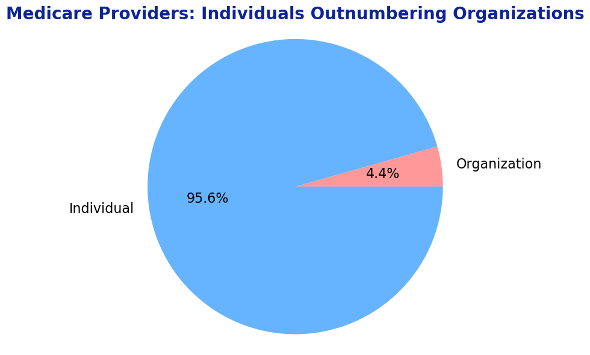

```python
# Plot the Number of Organization and Individuals
plot_by_entity(provider_service)
```

**Figure 2.** Plot: Number of Organizations and Individuals

#### Comments / Insights:

- Figure 2 reveals a notable difference between individual providers and organizations, with **individual providers** accounting for **95.6% (26.9M)** of the total, while **organizations** make up just **4.4% (1.2M)**. This suggests that the vast majority of services and prescriptions within the Medicare system are provided by individual practitioners, rather than larger organizations.
- The implications for the distribution of providers in Medicare can be attributed to various factors. **Individual providers** offer **increased accessibility**, particularly in underserved rural or remote areas where organizations may be lacking. They also provide a **wider range** of specialized healthcare services, prioritize building strong patient **relationships** for higher satisfaction and improved health outcomes, and demonstrate **flexibility** in adapting to evolving healthcare landscapes and regulations. The high proportion of individual providers indicates a **fragmented market** that caters to diverse patient needs.
- This result gives the team a realization that understanding the preferences and needs of beneficiaries receiving care from **individual providers** is crucial and could be used as a starting point in creating recommendations in the succeeding sections.

## 6.2 Distribution of Place of Service

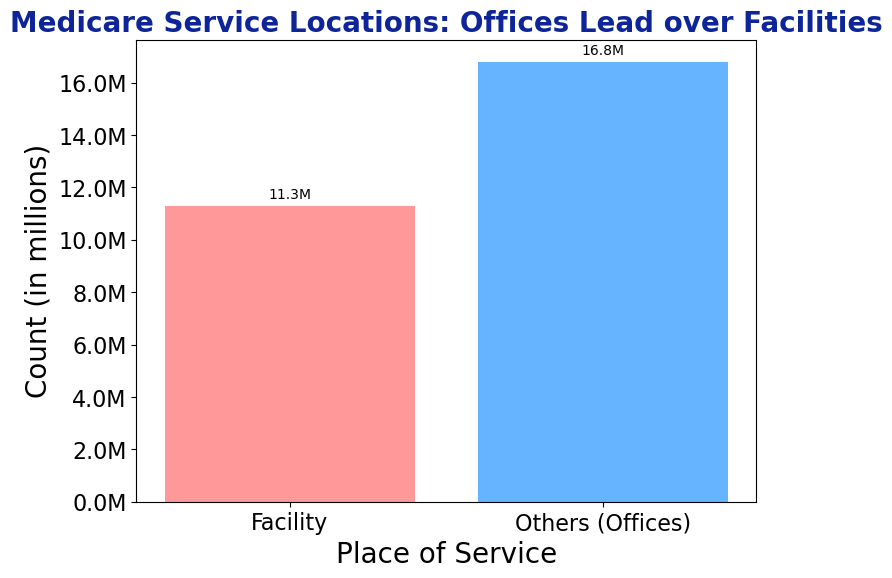

```python
# Plot the distribution of place of service
plot_place_of_service(provider_service.select('PLACE_OF_SERVICE', 'NPI'))
```

**Figure 3.** Plot Distribution of Place of Service

#### Comments / Insights:

- Figure 3 reveals a distribution of Medicare providers' place of service, with **11,302,906 instances in facilities** and **16,799,168 instances in other locations, such as offices**. This may imply that patients prefer the convenience, personalization, and potentially lower costs associated with care in offices.
- Higher number of instances in offices suggests a significant proportion of beneficiaries receive care in smaller, private settings which makes sense since most of the providers are individuals.

## 6.3 Medicare Participation Distribution

The **Medicare Participation Indicator** is a flag that indicates whether a healthcare provider participates in the Medicare program (`Y`) or not (`N`). Participating providers accept Medicare as payment for their services, while non-participating providers may choose to accept or not accept Medicare payments on a service-by-service basis.

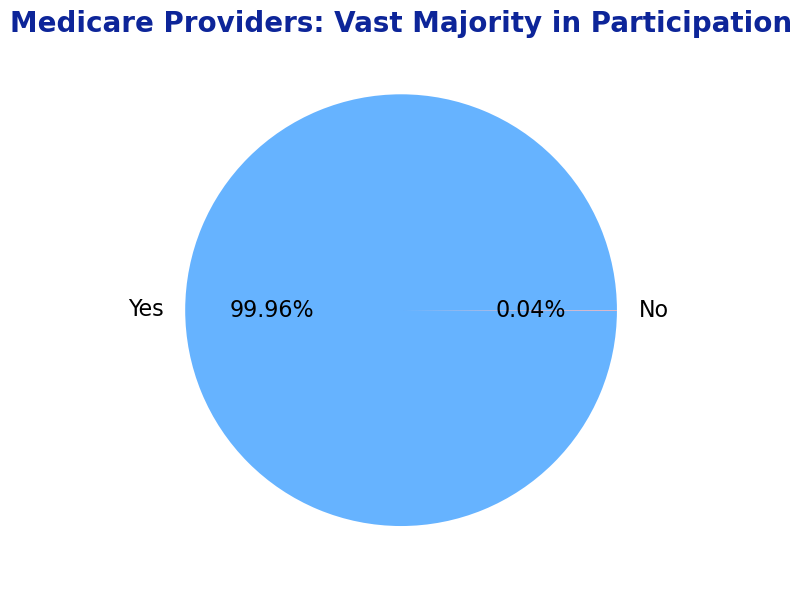

```python
# Plot by Medicare Participation Indicator
plot_by_medicare_participation(provider_service)
```

**Figure 4.** Plot Medicare Participation Distribution

#### Comments / Insights:

- Figure 4 reveals the Medicare participation status of providers, showing that 28,090,788 providers are participating (Y) in Medicare, while **only 11,286 providers are not participating (N)**.
- High participation rate indicates providers recognize the importance of serving Medicare beneficiaries
- This opens up **opportunity** for the insurance companies to increase market share by understanding and addressing the needs/requirements of non-participating providers and clients who choose non-participating providers.

## 6.4 Top 10 Provider Specialties

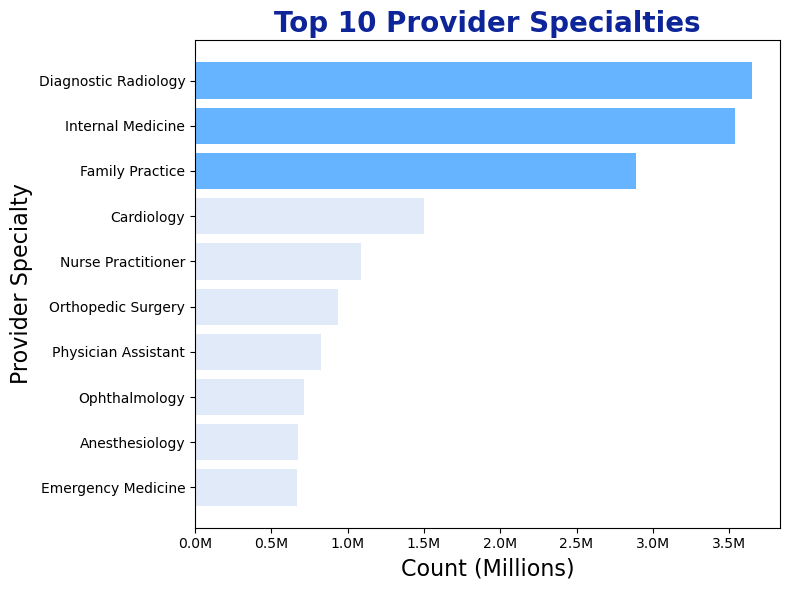

```python
# Plot the Top 10 Provider Specialties
plot_top_provider_specialties(provider_service)
```

**Figure 5.** Plot Top 10 Provider Specialties

#### Comments / Insights:

- Figure 5 illustrates the distribution of provider types in the Medicare dataset. It's clear that there are diverse specialties among the service providers, with some specialties more prevalent than others:
  - **Diagnostic Radiology**: With 3,650,817 entries, Diagnostic Radiology is the most common specialty in this dataset. The high number of diagnostic radiologists in the system indicates a high demand for diagnostic imaging services among the Medicare population.
  - **Internal Medicine**: The second most prevalent specialty is Internal Medicine with 3,536,170 entries. This suggests that a significant portion of Medicare services is dedicated to comprehensive adult healthcare, which emphasizes preventive medicine and overall patient wellness.
  - **Family Practice**: Third in line is Family Practice with 2,891,346 entries. This specialty often serves as the first point of contact for patients, offering broad-spectrum care. The prevalence of this specialty underscores the importance of general health maintenance and disease prevention.
- For the remaining specialties, we see a wide range of medical fields represented, including **Cardiology, Orthopedic Surgery, Ophthalmology, Anesthesiology,** and **Emergency Medicine**. Each of these specialties indicates different and specialized healthcare needs of the Medicare population.
- Lastly, the presence of **Nurse Practitioners** and **Physician Assistants** in the top ten specialties signifies the vital role of these healthcare professionals in providing care to the Medicare population. It may be beneficial for insurance companies to acknowledge their role in their policies, possibly offering coverage that directly involves care from these professionals.

## 6.5 Top Specialties by Submitted Charges

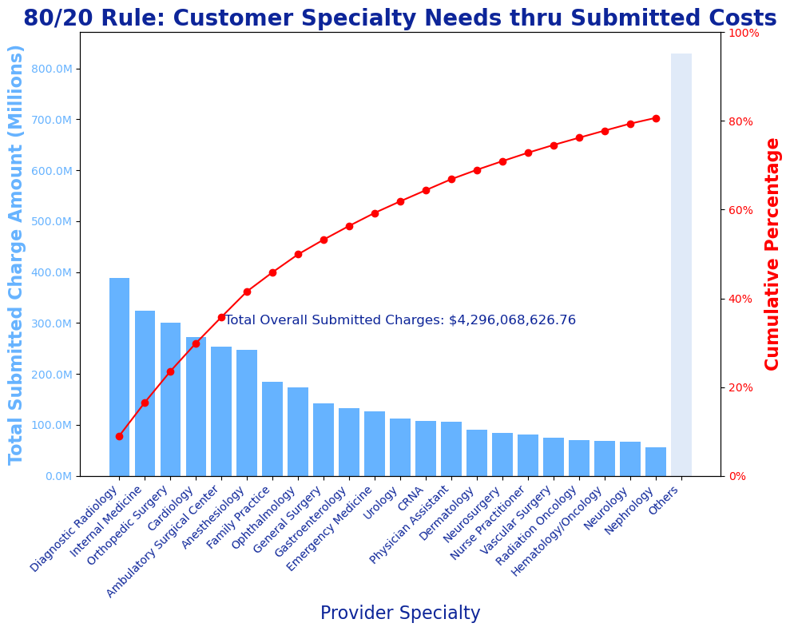

```python
# Pareto chart of top provider specialties by submitted charge amounts
plot_pareto_specialties_by_submitted_charges(provider_service)
```

**Figure 6.** Plot Pareto Chart by Total Submitted Charges

#### Comments / Insights:

- Figure 6 provides insight into the distribution of average submitted charges by different provider specialties in the CMS dataset. A total of 22 out of 91 specialties contribute to 80% of the total submitted charges, which amounts to approximately `$4.3 billion`.
- `Diagnostic Radiology` leads the pack, contributing to the highest average submitted charges of approximately `$388 million`. This could be attributed to the high cost of imaging equipment, maintenance, and the specialized training required to interpret these imaging studies.
- `Internal Medicine`, `Orthopedic Surgery`, `Cardiology` follow closely, with average submitted charges of approximately `$324 million`, `$301 million`, and `$272 million`, respectively. The high cost in `Internal Medicine` could be reflective of the broad range of diseases and conditions they manage, often serving as primary care physicians. `Orthopedic Surgery`, on the other hand, involves complex surgical procedures, often requiring costly implants and longer hospital stays which can drive up the costs. While `Cardiology` is specialized for life-threatening heart diseases that are usually highly expensive.
- Interestingly, `Ambulatory Surgical Centers` rank fifth with an average submitted charge of around `$253 million`. These centers could be submitting high charges due to the variety of same-day surgical procedures they perform, which often require expensive medical equipment and supplies but slightly alleviated by shorter/one day hospital stays only.
- `Anesthesiology`, `Family Practice`, and `Ophthalmology` also contribute significantly to the overall charges, indicative of their crucial roles in patient care. `Anesthesiology`, given its integral role in surgeries, might account for the high charges due to the risk and complexity involved in the services provided.
- On the lower end of the spectrum, specialties such as `Hematology`, `Neurology`, and `Nephrology` have comparatively lower average submitted charges, although still significant, ranging from approximately `$56 million` to `$68 million`. It's worth noting that these specialties often involve less invasive procedures and focus more on diagnosis, treatment, and prevention that may not require expensive equipment or prolonged hospital stays, which could explain their lower relative costs.
- The disparities in average submitted charges across specialties can be attributed to various factors including procedure complexity, cost of equipment, and length of hospital stay. Note that these figures reflect the charges submitted, not necessarily the amount reimbursed by Medicare, which often pays a fraction of the submitted charges. So the team will compare this with the result of top specialties by average medicare payment amounts to spot potential inefficiencies in the current insurance coverage model and highlight areas that might benefit from policy changes.

## 6.6 Top Specialties by Medicare Payment Amount

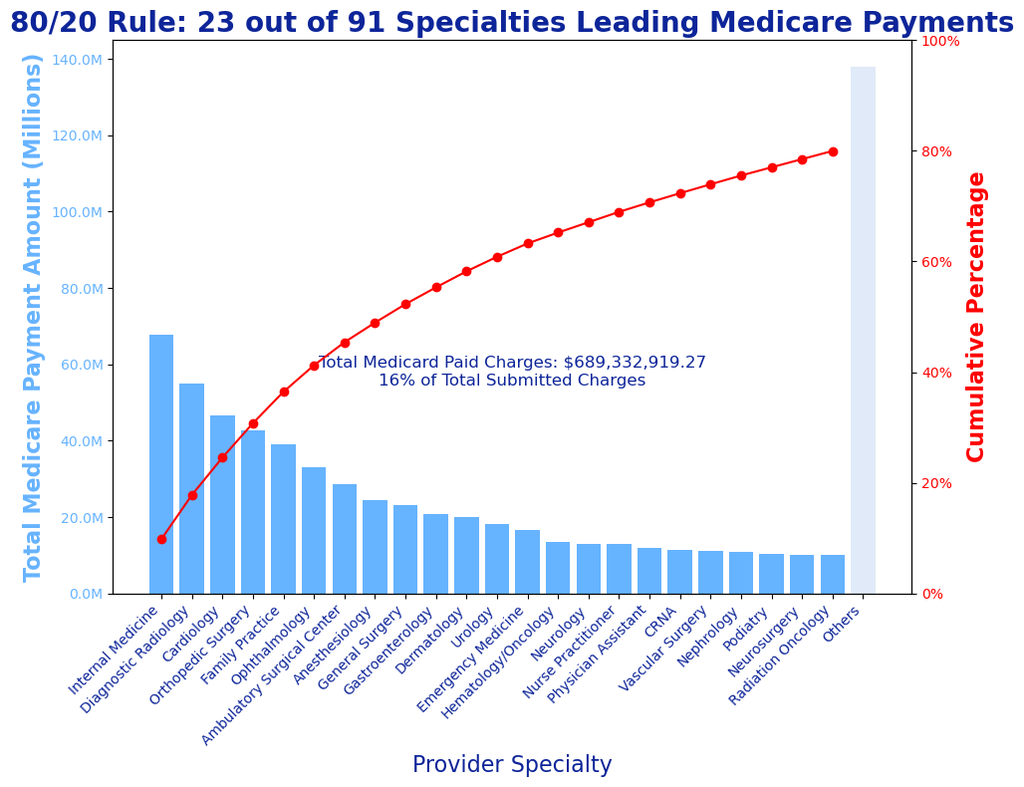

```python
# Pareto chart of top provider specialties by medicare payment amounts
plot_pareto_specialties_by_payment_charges(provider_service)
```

**Figure 7.** Plot Pareto Chart by Total Medicare Payment Amount

## 6.7 Specialties by % of Medicare Covered

```python
# Top 15 Specialties by % Medicare Covered
display(HTML(f'<left><span style="color:gray; font-size:16px"><b>Table 8. '
             f'</b>Top 15 Specialties by % Medicare Covered</span></left>'))
display(medicare_covered(provider_service).head(15))
```

**Table 8.** Top 15 Specialties by % Medicare Covered

|  | PROVIDER_TYPE | total_submitted_charges | total_medicare_payment | % medicare covered |
| --- | --- | --- | --- | --- |
| 0 | Pharmacy | 1,473.66 | 606.25 | 41.14 |
| 1 | Public Health Welfare Agency | 103,530.15 | 26,651.93 | 25.74 |
| 2 | Optometry | 33,447,894.00 | 8,128,614.50 | 24.30 |
| 3 | Slide Preparation Facility | 8,457.34 | 2,032.33 | 24.03 |
| 4 | Registered Dietician/Nutrition Professional | 322,867.81 | 75,980.42 | 23.53 |
| 5 | Chiropractic | 4,921,738.50 | 1,157,758.50 | 23.52 |
| 6 | Podiatry | 43,782,524.00 | 10,235,100.00 | 23.38 |
| 7 | Mass Immunization Roster Biller | 8,679,073.00 | 2,020,958.75 | 23.29 |
| 8 | Psychologist (billing independently) | 175,903.27 | 40,707.71 | 23.14 |
| 9 | Certified Nurse Midwife | 171,483.11 | 39,470.56 | 23.02 |
| 10 | Allergy/Immunology | 4,851,863.00 | 1,097,984.12 | 22.63 |
| 11 | Dermatology | 90,510,856.00 | 19,979,270.00 | 22.07 |
| 12 | Speech Language Pathologist | 395,491.09 | 86,639.06 | 21.91 |
| 13 | Unknown Supplier/Provider | 152,416.64 | 33,384.89 | 21.90 |
| 14 | Geriatric Medicine | 6,265,176.50 | 1,370,249.12 | 21.87 |

#### Comments / Insights:

- Table 8 illustrates the percentage of total submitted charges that Medicare covers for various provider types. Interestingly, `Pharmacy` stands out with Medicare covering `41.14%` of its submitted charges, even though the total charges are relatively low. This underlines the significant role pharmacies play in healthcare, particularly for Medicare beneficiaries who are major consumers of prescription drugs.
- `Public Health Welfare Agency` and `Slide Preparation Facility` show a substantial proportion of their charges being covered by Medicare (`25.74%` and `24.03%` respectively), despite having relatively low total submitted charges. This suggests that these provider types, although not directly involved in patient treatment, are still essential components of the healthcare system.
- Both `Optometry` and `Podiatry` have submitted charges in the millions, with Medicare covering around a quarter of these amounts. This reflects the high prevalence of eye and foot conditions, thus the significant Medicare coverage.
- The `Mass Immunization Roster Biller` has almost a quarter (`23.29%`) of its charges covered by Medicare. This is indicative of the importance that Medicare places on preventative health measures like immunizations.
- `Dermatology`, despite having large total submitted charges, sees only `22.07%` of these charges covered by Medicare. This might be due to the nature of dermatological treatments, many of which could be considered elective or cosmetic and thus not fully covered by Medicare, but still high enough coverage as compared with other life threatening-related specialties. One theory is that Medicare wants to capture this type of market segment.

```python
# Bottom 10 Specialties by % Medicare Covered
display(HTML(f'<left><span style="color:gray; font-size:16px"><b>Table 9. '
             f'</b>Bottom 10 Specialties by % Medicare Covered</span></left>'))
display(medicare_covered(provider_service).tail(10))
```

**Table 9.** Bottom 10 Specialties by % Medicare Covered

|  | PROVIDER_TYPE | total_submitted_charges | total_medicare_payment | % medicare covered |
| --- | --- | --- | --- | --- |
| 81 | Sleep Medicine | 726,314.12 | 89,053.80 | 12.26 |
| 82 | Pain Management | 14,928,815.00 | 1,823,903.00 | 12.22 |
| 83 | Neurosurgery | 84,158,896.00 | 10,215,419.00 | 12.14 |
| 84 | Ambulatory Surgical Center | 253,157,552.00 | 28,716,334.00 | 11.34 |
| 85 | Physician Assistant | 106,680,704.00 | 11,842,340.00 | 11.10 |
| 86 | CRNA | 107,789,336.00 | 11,383,491.00 | 10.56 |
| 87 | Anesthesiology | 247,898,304.00 | 24,431,400.00 | 9.86 |
| 88 | Anesthesiologist Assistants | 3,136,940.50 | 284,036.84 | 9.05 |
| 89 | Unknown Physician Specialty Code | 791,810.62 | 61,652.09 | 7.79 |
| 90 | Interventional Cardiology | 5,777,983.00 | None | None |

#### Comments / Insights:

- The provider types listed in Table 9 reveal those receiving the lowest percentage of their total submitted charges from Medicare.
- `Sleep Medicine` and `Pain Management` specialties have their charges covered by Medicare at similar rates, approximately `12%`. This may reflect the complex nature of these specialties, where treatment plans often involve multiple services which might be individually reimbursed at different rates.
- `Neurosurgery` has a slightly lower percentage of Medicare coverage at `12.14%`, despite significantly higher submitted charges. This could be due to the high complexity and cost of neurosurgical procedures, which might not be fully recognized in the Medicare reimbursement models.
- `Ambulatory Surgical Center` and `Physician Assistant` both have charges in the hundreds of millions, with coverage percentages of `11.34%` and `11.10%` respectively. The relatively low coverage percentage could be reflective of the high volume and diversity of services provided in these settings.
- `CRNA`, `Anesthesiology`, and `Anesthesiologist Assistants` show lower Medicare coverage percentages, ranging from `10.56%` to `9.05%`. This pattern suggests that anesthesia-related services are less likely to be fully covered by Medicare, possibly due to bundled payment models for surgical services.
- The `Unknown Physician Specialty Code` category has a very low Medicare coverage rate of `7.79%`. Lack of specificity in billing codes could be a factor here, leading to lower reimbursements.
- `Interventional Cardiology` stands out as having no recorded Medicare payment. Reasons could range from billing errors to non-compliance with Medicare's policies, or it could indicate services not typically covered by Medicare.

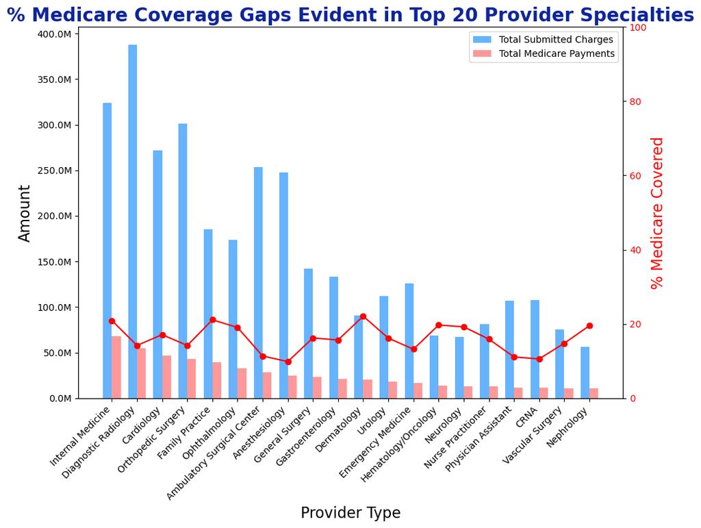

```python
# Plot % Medicare Covered of the Top 20 Provider Specialties
plot_medicare_coverage(calculate_sum_by_provider_type(provider_service))
```

**Figure 8.** Plot by % Medicare Covered

## 6.8 Submitted Charges & Payments by Country and City

The following data provides tables and visualizations about the submitted charges and payment comparison between US and non-US countries, top 10 non-US countries based on submitted charges, and top 10 US cities based on submitted charges.

```python
# Display Claims, Payments, and Beneficiary Count between US and Non-US
display(HTML(f'<left><span style="color:gray; font-size:16px"><b>Table 10. '
             f'</b>Claims, Payments, and Beneficiary count between US and '
             f'Non-US</span></left>'))
display_charge_beneficiary_average(provider_service)
```

**Table 10.** Claims, Payments, and Beneficiary count between US and Non-US

|  | NPPES_PROVIDER_COUNTRY | AVERAGE_SUBMITTED_CHRG_AMT | AVERAGE_MEDICARE_PAYMENT_AMT | BENE_DAY_SRVC_CNT |
| --- | --- | --- | --- | --- |
| 0 | Non-US | 205.03 | 77.11 | 67.406516 |
| 1 | US | 152.87 | 74.22 | 148.705051 |

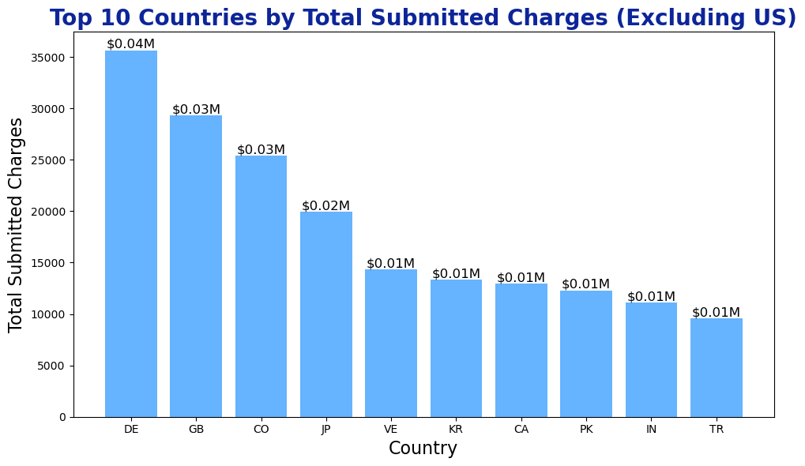

```python
# Plot Top 10 Country by Total Submitted Charges (Excluding US)
plot_top_non_us_countries_by_submitted_charges(provider_service, n=10)
```

**Figure 9.** Plot Top 10 Non-US Countries by Total Submitted Charges

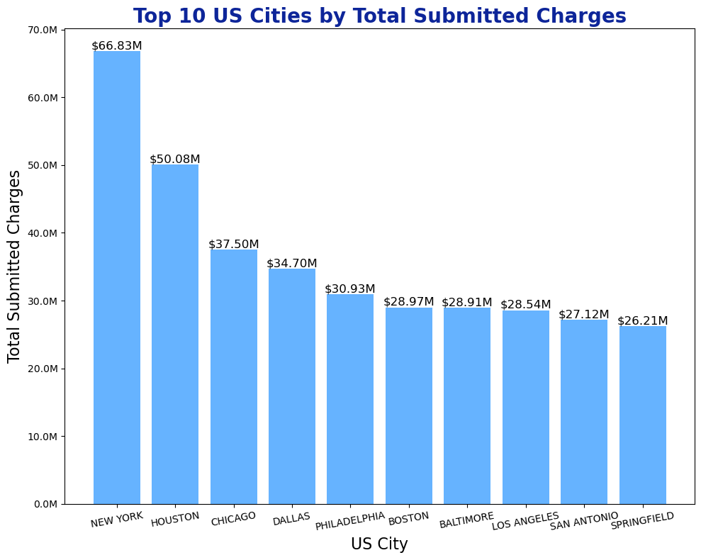

```python
# Plot Top 10 US Cities by Total Submitted Charges
plot_top_us_cities_by_submitted_charges(provider_service, n=10)
```

**Figure 10.** Plot Top 10 US Cities by Total Submitted Charges

#### Comments / Insights:

- Table 10, Figure 9, and Figure 10 suggests claims and payment disparity between cities and countries. Some notable insights are summarized as follows:
  - **Higher Average Charges for Non-US Providers**: The average submitted charge for services by providers located outside the United States is higher (`$205.03`) compared to those within the United States (`$152.87`). However, the average Medicare payment is not that significantly different between both groups, with Non-US at `$77.11` and US at `$74.22`. This suggests that non-US providers tend to submit higher claims, but Medicare payments remain relatively consistent regardless of the provider's country.
  - **Greater Volume of Services in the US**: Despite the higher average charges from Non-US providers, the average number of services (BENE_DAY_SRVC_CNT) provided per beneficiary is significantly higher in the US (149) compared to Non-US (67). This could be due to factors such as accessibility, patient preferences, or differences in the scope of services provided. Also, while Non-US providers may charge more on average, US providers are servicing beneficiaries more frequently.
  - **US Dominates in Total Submitted Charges**: As expected, the total submitted charges by US providers far outstrip those from providers in other countries. This is likely due to the sheer number of providers and volume of services provided in the US. Among non-US countries, Germany (DE), Great Britain (GB), and Colombia (CO) lead in total submitted charges.
  - **Major US Cities Lead in Total Charges**: Major US cities, including New York, Houston, and Chicago, are the leading sources of total submitted charges. This is likely due to these cities having large populations, high concentrations of healthcare providers, and possibly more complex and expensive healthcare needs.

## 6.9 Top 10 Drugs by Total Claims

```python
# Display the count of unique drugs covered by Medicare
count_unique_drugs = provider_drug.select('generic_name').distinct().count()
display(HTML(f'<b>Unique Number of Drugs Covered: {count_unique_drugs}</b>'))
```

**Unique Number of Drugs Covered: 2000**

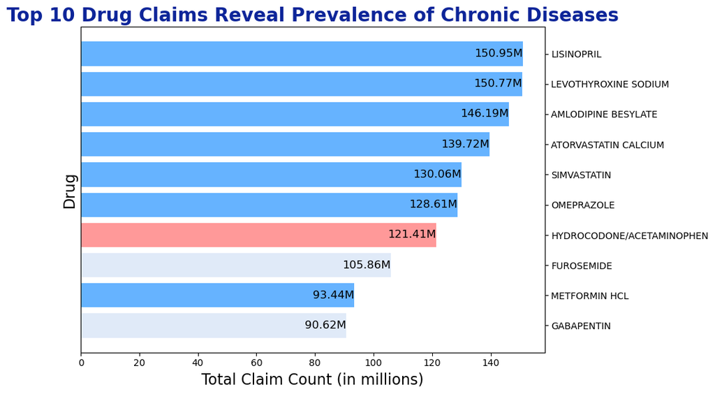

```python
# Top 10 Prescribed Drugs by Total Claims
plot_top_prescribed_drugs(provider_drug, n=10)
```

**Figure 11.** Plot Top 10 Drug by Total Claims

#### Comments / Insights:

- **High Prevalence of Chronic Diseases** (Blue): Figure 11 shows that the majority of the top 10 drugs are used to manage chronic conditions. Lisinopril (hypertension), Levothyroxine Sodium (hypothyroidism), Amlodipine Besylate (high blood pressure), Atorvastatin Calcium (high cholesterol), Simvastatin (high cholesterol), Metformin HCL (diabetes), and Omeprazole (acid reflux) are all used to treat long-term health conditions. This suggests that chronic diseases are prevalent among Medicare beneficiaries, which aligns with known demographic trends.
- **Pain Management** (Pink): Hydrocodone-Acetaminophen, an opioid used for pain management, is among the top 10 claimed drugs. This may indicate a high demand for pain management among Medicare beneficiaries. However, it also raises concerns about potential opioid misuse or overuse.
- **Heart Health and Cardiovascular Disease**: Several of the drugs listed (Lisinopril, Amlodipine Besylate, Atorvastatin Calcium, Simvastatin) are used to manage heart health and hypertension, indicating a high prevalence of cardiovascular diseases among the Medicare population. Cardiovascular diseases are a leading cause of death and disability in the U.S., particularly among older adults, so it's not surprising to see these medications among the most claimed.
- **Mental Health** (Light blue): Gabapentin, often used for nerve pain and certain types of seizures, is also sometimes prescribed off-label for anxiety. Its presence on this list could indicate a substantial need for mental health and neurological care among Medicare beneficiaries.
- **Cost Management Opportunities**: Given the high total claim count for these drugs, there could be significant opportunities for cost savings through strategies such as promoting the use of generic versions, negotiating bulk pricing deals, or implementing medication therapy management programs to ensure these drugs are being used effectively.

## 6.10 Age Group Distribution by Total Claims

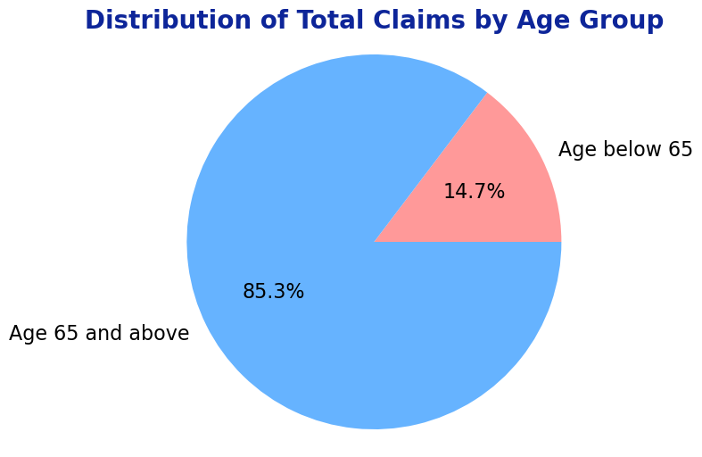

```python
# Plot the distribution of total claims by age group
plot_age_group_distribution(provider_drug)
```

**Figure 12.** Plot Distribution of Total Claims by Age Group

#### Comments/Insights:

- **Significant Medicare Utilization Among Elderly**: Figure 12 shows a significantly higher number of claims made by individuals aged 65 and above. This suggests a high dependency on Medicare among the elderly population, which is expected as health issues tend to increase with age.
- **Higher Health Care Needs for Older Adults**: The substantial difference in claim numbers between the two groups may reflect the higher healthcare needs of older adults, who are more likely to have chronic conditions or require regular medical attention.
- **Policy Focus on Elderly Care**: Given the high number of claims from individuals aged 65 and above, it's clear that a significant proportion of Medicare resources are allocated to this group. This underscores the importance of policies and strategies aimed at managing the health of older adults, such as preventive care, chronic disease management, and coordination of care.
- **Importance of Preventive Care in Younger Population**: The lower number of claims in the below 65 age group highlights the potential importance of preventive care and healthy lifestyle promotion in this group to maintain their health status and potentially reduce future Medicare claims as they age.
- **Potential for Future Demand**: As the population ages, the number of Medicare beneficiaries will likely increase, and so too will the number of claims. This trend could have significant implications for healthcare planning and resource allocation in the future.

## 6.11 Top Specialties by Total Claims

```python
# Display the count of unique drugs covered by Medicare
count_unique_specialties = provider_drug.select('specialty_description').distinct().count()
display(HTML(f'<b>Unique Number of Specialties: {count_unique_specialties}</b>'))
```

**Unique Number of Specialties: 242**

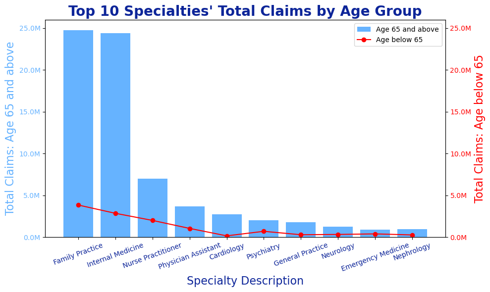

```python
# Plot the Top 10 Specialties' total claims by age group
plot_top_specialties(provider_drug)
```

**Figure 13.** Plot Total Claims of Top 10 Specialties by Age Group

#### Comments/Insights:

- **Primary Care Specialties Have the Most Claims**: In Figure 13, out of the 242 unique specialties, `Family Practice` and `Internal Medicine`, which are primary care specialties, have the most claims for both age groups. This suggests that these specialties are the first point of contact for many patients and handle a wide variety of health issues. It also underscores the importance of primary care in overall healthcare delivery and its role in managing chronic diseases, which are prevalent in both age groups but particularly in those aged 65 and above.
- **Higher Utilization of Nurse Practitioners and Physician Assistants in the Elderly**: `Nurse Practitioners` and `Physician Assistants` have a higher number of claims in the 'Age 65 and above' group compared to the 'Age below 65' group. This could indicate that these healthcare professionals play a significant role in managing the health of the elderly, possibly due to their focus on patient-centered, preventive, and chronic care.
- **Specialist Care for Age-Specific Conditions**: Specialties like `Cardiology`, `Psychiatry`, `Neurology`, and `Nephrology` show higher claim numbers in the 'Age 65 and above' group, reflecting the prevalence of age-related conditions like heart disease, mental health issues, neurological disorders, and kidney diseases in this age group.

Back to TOC

# 7. RESULTS AND DISCUSSION

In this report, the team performed descriptive analytics and visualization of the CMS Data by Provider and Service as well as by Provider and Drug in order to derive insights into patterns of utilization, payment, submitted charges, and drug claims of the insured policy holders. The main objective was to identify potential opportunities for insurance companies to optimize their policy and coverage options and improved healthcare delivery to Medicare beneficiaries. The following summarizes the insights and comments from sections 6.1 to 6.11 of the report, focusing on key findings relevant to the problem statement:

- **Healthcare Service Utilization**: Primary care specialties - particularly `Internal Medicine` and `Family Practice` - were identified as the most frequently utilized services, reflecting their crucial role as the first point of care. This pattern remained consistent across various age groups, with a higher volume of claims in the `65 and above` age group. `Nurse Practitioners` and `Physician Assistants` also had a higher number of claims in the elderly population, signaling a shift towards more patient-centered, preventive, and chronic care. This could suggest the need for further integration of these roles into the healthcare delivery model, particularly for elder care.
- **Healthcare Costs and Payments**: `Internal Medicine` led in average Medicare payments, likely due to the complex, ongoing management of chronic conditions. Interestingly, `Diagnostic Radiology`, despite having the highest submitted charges, ranked second in Medicare payments, possibly due to Medicare's reimbursement policies paying only a fraction of submitted charges.
- **Specialties and Medicare Coverage**: `Pharmacy` stood out with Medicare covering 41.14% of its submitted charges, highlighting the vital role pharmacies play in healthcare, particularly for Medicare beneficiaries who are major consumers of prescription drugs. `Dermatology` was also part of the top of Medicare coverage, possibly due to specific procedures being more favorably reimbursed by Medicare. In contrast, specialties like `Sleep Medicine`, `Pain Management`, and `Neurosurgery` had their charges covered by Medicare at lower rates, potentially due to the complexity of these services.
- **Healthcare Cost Differences Across Geographical Locations**: `Non-US providers` submitted higher average charges for services than `US providers`. However, the average Medicare payment did not significantly differ between the two groups. Additionally, US providers offered a higher average number of services, suggesting more frequent servicing of beneficiaries.
- **Prescription Drug Utilization**: The majority of the top 10 claimed drugs were used to manage chronic conditions, reflecting the high prevalence of chronic diseases among Medicare beneficiaries. Notably, an opioid used for pain management was among the top claimed drugs, indicating a potential area of concern for misuse or overuse.
- **Demographics and Healthcare Utilization**: A significantly higher number of claims were made by individuals `aged 65 and above`, emphasizing the high dependency on Medicare among the elderly population. The lower number of claims in the `below 65 age` group underlines the potential importance of preventive care and healthy lifestyle promotion in this group to potentially reduce future Medicare claims as they age.
- **Age-Related Specialization**: The higher claim numbers for `Cardiology`, `Psychiatry`, `Neurology`, and `Nephrology` in the `Age 65 and above` group indicate a prevalence of age-related conditions like heart disease, mental health issues, neurological disorders, and kidney diseases. This finding could guide targeted interventions and health promotion efforts within these specialties for this age group.
- **Preference for Individual Providers**: The dominance of `individual providers` over organizations in Medicare claims suggests that the healthcare market within Medicare is highly fragmented. This could be attributed to the increased accessibility of `individual providers`, their ability to offer a wide range of specialized services, and their flexibility in adapting to changing healthcare landscapes. It also indicates a preference among beneficiaries for the personalized care and strong patient-provider relationships that `individual providers` can offer.
- **Location of Service Delivery**: The distribution of service locations, with a higher number of instances in `offices` compared to `facilities`, may indicate a preference among patients for the convenience and potentially lower costs associated with care in these settings. This finding highlights the significant role of smaller, private settings in healthcare delivery, which aligns with the dominance of `individual providers` in Medicare.
- **Medicare Participation Rate**: The high participation rate of providers in Medicare underscores the program's importance in serving beneficiaries. However, the presence of non-participating providers also signals potential opportunities for expanding coverage. Understanding the needs and requirements of these providers, as well as the beneficiaries who choose them, could help insurance companies increase their market share and improve healthcare accessibility for beneficiaries.

Back to TOC

# 8. CONCLUSION

Through an extensive analysis of the CMS Data by Provider and Service as well as by Provider and Drug, the team has successfully derived critical insights into the patterns of healthcare utilization, payments, submitted charges, and drug claims within the Medicare system. The team's findings have addressed the problem statement, revealing potential opportunities for insurance companies to optimize their policy and coverage options, and providing a roadmap for improved healthcare delivery to Medicare beneficiaries.

The team identified primary care as the cornerstone of healthcare services, with a significant volume of claims stemming from primary care specialties. The data also underlined the growing importance of Nurse Practitioners and Physician Assistants, especially in the care of the elderly, signifying the shift towards more patient-centered and chronic care.

Medicare payments were highest for Internal Medicine, reflecting the intricate and ongoing management of chronic conditions in this specialty. However, the discrepancy between submitted charges and Medicare payments, particularly in specialties like Diagnostic Radiology, highlighted potential areas for cost optimization within the Medicare system.

The team further observed that the distribution of healthcare service providers and delivery locations were skewed towards individual providers and office-based services. This indicated a preference among Medicare beneficiaries for personalized care and stronger patient-provider relationships.

Moreover, the team uncovered disparities in healthcare costs and service utilization across geographical locations and between different age groups. This emphasized the need for tailored approaches to healthcare delivery based on demographic and geographical considerations.

Finally, the team found that non-participating providers in the Medicare system present an opportunity for insurance companies to expand their coverage and market share. Understanding the needs and preferences of these providers and the beneficiaries who choose them could inform strategies for increased participation.

Through this comprehensive analysis, the team has achieved a nuanced understanding of the dynamics of healthcare utilization, costs, and service delivery within the Medicare system. These insights offer valuable guidance for insurance companies aiming to optimize their policies and improve the quality of healthcare delivery for Medicare beneficiaries. By addressing the problem statement, the team's work is poised to facilitate more efficient, cost-effective, and patient-centered healthcare services in the Medicare system. Further details can be explored in the `Recommendation` section.

Back to TOC

# 9. RECOMMENDATION

Based on the insights derived from the analysis, the team presented the data assumptions and limitations, and proposed the following recommendations for immediate implementation and future work:

## 9.1 Data Assumptions and Limitations

The analyses presented in this report are based on a set of underlying assumptions and limitations associated with the data. Key assumptions and limitations identified during the creation of this report are as follows:

**Assumptions:**

- The analysis assumes that the provided data is complete and accurately represents the entire Medicare beneficiary population, including providers, services, and prescriptions.
- It is assumed that the data entries, including provider information, drug details, payments, submitted charges, and drug cost claims, are accurate and reliable.
- The analysis assumes uniform and consistent categorization of providers, services, and drugs across all data entries, enabling valid comparisons.

**Limitations:**

- The data used in this analysis covers a specific time period (years 2013 to 2016), potentially limiting the capture of changes in provider behavior, service utilization, and prescription drug use over time.
- Clinical data, such as diagnosis, severity of illness, and comorbidities, is not included in the dataset, which could provide additional context to the observed utilization patterns and cost differences.
- Detailed demographic information about beneficiaries, such as socioeconomic status, education level, and ethnicity, is not available in the dataset, potentially limiting the understanding of factors influencing healthcare utilization and costs.
- The data only encompasses services and prescriptions covered by Medicare, excluding any healthcare utilization or prescriptions outside of the program, which may result in an incomplete representation of the overall healthcare landscape.
- Provider characteristics, including years of experience, training background, and quality ratings, are not included in the dataset, limiting the assessment of the quality of care and associated costs.

## 9.2 For Immediate Implementation

- **Revise Primary Care Coverage and Premiums:** Given the significant role of primary care services in managing beneficiaries' health, consider increasing Medicare coverage for these services. However, to balance this increase and maintain profitability, adjust the insurance premiums accordingly. For example, if Medicare coverage for preventive care services is increased by 3% from the current rate, a corresponding increase of 5-7% in premiums could be applied (this is just an example, a more comprehensive financial cost-benefit analysis as well as risk assessment studies should be thoroughly performed, but this could be the starting point to prioritize focus). This approach not only improves patient outcomes but also ensures the sustainability of the insurance program.
- **Adjust Reimbursement for Nurse Practitioners and Physician Assistants:** Increase the reimbursement rates for services provided by `Nurse Practitioners` and `Physician Assistants` by specific percentage. Simultaneously, consider introducing a co-payment system for these services, which will maintain revenue flow while incentivizing the utilization of these professionals.
- **Standardize Service Costs:** Implement a policy that standardizes the cost of services between `US` and `non-US providers`. This will create predictability in costs and allow the insurance company to better manage its risk and pricing models.
- **Incentivize Non-Participating Providers:** Encourage non-participating providers to join the Medicare system by offering higher initial reimbursement rates. Once these providers join the system, introduce a tiered reimbursement model that incentivizes efficiency and quality of care. Marketing or informing them of higher reimbursement rate during the first year or other incentives to encourage them to join could increase market share.

## 9.3 For Future Work

- **Specialty-Specific Premiums:** For specialties like `Sleep Medicine`, `Pain Management`, and `Neurosurgery`, consider introducing specialty-specific premiums. These premiums could be slightly higher than the general premium to account for the higher cost of these complex services, thus increasing overall profitability.
- **Revise Prescription Drug Coverage:** Conduct a detailed analysis of prescription drug utilization, particularly for high-cost drugs. Based on this analysis, consider revising the drug coverage to introduce tiered co-payment models where beneficiaries share more cost for high-cost drugs.
- **Risk-Based Premiums:** Develop a risk stratification model for beneficiaries. Based on their risk scores, adjust their premiums accordingly. High-risk beneficiaries would have higher premiums, reflecting their potential higher healthcare costs.
- **Invest in Data Infrastructure:** Improved data collection and analysis capabilities can provide more accurate and timely information for decision making. Better understanding of provider behaviors, patient needs, and service utilization can lead to more efficient service provision and pricing strategies, thereby enhancing profitability.
- **Targeted Health Promotion Programs:** Implement health promotion programs aimed at preventing the onset of chronic diseases among the 'below 65 age' group. While this requires initial investment, it could lead to reduced healthcare costs in the long term as these beneficiaries age, thus leading to higher profitability.
- To make well-informed decisions regarding policy changes, it is advisable for the company to incorporate additional data into this study. This can involve incorporating actual financial statements, as well as considering competitor policy coverage and pricing.

Back to TOC

# REFERENCES

[1] Centers for Medicare & Medicaid Services. (n.d.). Medicare Physician & Other Practitioners - by Provider and Service. CMS.gov. https://data.cms.gov/provider-summary-by-type-of-service/medicare-physician-other-practitioners/medicare-physician-other-practitioners-by-provider-and-service

[2] Centers for Medicare & Medicaid Services. (n.d.). Medicare Part D Prescribers - by Provider and Drug. CMS.gov. https://data.cms.gov/provider-summary-by-type-of-service/medicare-part-d-prescribers/medicare-part-d-prescribers-by-provider-and-drug

[3] Centers for Medicare & Medicaid Services. (n.d.). Medicare Physician & Other Practitioners - by Provider and Service data dictionary. CMS.gov. https://data.cms.gov/resources/medicare-physician-other-practitioners-by-provider-and-service-data-dictionary.

[4] Centers for Medicare & Medicaid Services. (n.d.). Medicare Part D Prescribers - by Provider and Drug data dictionary. CMS.gov. https://data.cms.gov/resources/medicare-part-d-prescribers-by-provider-and-drug-data-dictionary.

Back to TOC